# Aside

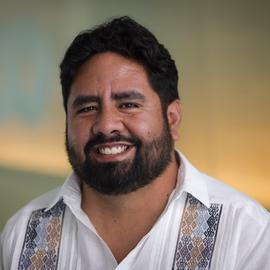

[Download a PDF of this CV](http://lcolladotor.github.io/cv/en_CV_lcollado.pdf)

## Contact

- lcolladotor@gmail.com
- lcolladotor
- lcolladotor
- lcolladotor.github.io
- [Team website](http://lcolladotor.github.io/bioc_team_ds/)
- [lcollado](https://linkedin.com/in/lcollado/)
- [ORCiD](http://orcid.org/0000-0003-2140-308X)
- [Google Scholar](http://scholar.google.com/citations?user=h57-MykAAAAJ)
- [Speaker Deck](http://www.speakerdeck.com/lcolladotor/)
- [slideshare](http://www.slideshare.net/lcolladotor/)
- [publons](https://publons.com/a/1262671)
- [NIH Reporter](https://reporter.nih.gov/search/BCANb0yo9kiLuoMyy6y42w/projects)

## Language Skills

R

Bash

Git/GitHub

## Disclaimer

Made with the R package [**pagedown**](https://github.com/rstudio/pagedown). The source code is available at lcolladotor/cv and is powered by nstrayer/cv.

Last updated on 2026-08-03.

# Main

## Leonardo Collado-Torres

At the Lieber Institute for Brain Development ([LIBD](https://www.libd.org/)), as part of the Translational Neuroscience Division, I lead the [**R/Bioconductor-powered Team Data Science**](https://lcolladotor.github.io/) group that works on understanding the roots and signatures of disease (particularly psychiatric disorders) by zooming in across dimensions of gene activity. We achieve this by studying gene expression at all expression feature levels (genes, exons, exon-exon junctions, and un-annotated regions) and by using different gene expression measurement technologies (bulk RNA-seq, single cell/nuclei RNA-seq, and spatial transcriptomics) that provide finer biological resolution and localization of gene expression. My group works closely with collaborators from LIBD as well as from Johns Hopkins University (JHU), University of Cambridge, and other institutions, which reflects the cross-disciplinary approach and diversity in expertise needed to further advance our understanding of high throughout biology. I am also interested in outreach activities as a board member of the [Community of Bioinformatics Software Developers](https://comunidadbioinfo.github.io/#people). In order to provide a supportive and stimulating research environment at LIBD, my group provides [Data Science guidance sessions](https://lcolladotor.github.io/bioc_team_ds/data-science-guidance-sessions.html) open to any LIBD staff member and organizes the [LIBD rstats club](http://research.libd.org/rstatsclub/#.YEvDq2RKgdk), among other initiatives.

As a quick background, I graduated from the [Undergraduate Program on Genomic Sciences](http://www.lcg.unam.mx/about) from the National Autonomous University of Mexico ([UNAM](http://unam.mx/)) in 2009 and worked for two years at Winter Genomics analyzing high-throughput sequencing data. I then got a PhD in 2016 from the [Department of Biostatistics](http://www.jhsph.edu/departments/biostatistics/) at [Johns Hopkins Bloomberg School of Public Health](http://www.jhsph.edu/) thanks to a [CONACyT scholarship](http://www.conacyt.gob.mx/). There I worked with [Jeff Leek](http://jtleek.com/) and [Andrew Jaffe](http://aejaffe.com/) in developing derfinder and recount. I then worked ~ 4 years as a Staff Scientist and Research Scientist in Andrew Jaffe’s lab on a variety of data analysis projects. I became a principal investigator in September 2020 and an Assistant Professor in 2023.

Every day I use [R](http://cran.r-project.org/) and [Bioconductor](http://www.bioconductor.org/), and on some days I [write R packages](https://lcolladotor.github.io/pkgs/). Occasionally I write [blog posts](http://lcolladotor.github.io/#blog) about them and other tools. I’m a co-founder of the [LIBD rstats club](http://LieberInstitute.github.io/rstatsclub/) and the [CDSB community](https://comunidadbioinfo.github.io) of R and Bioconductor developers in Mexico and Latin America, just like we described at the [R Consortium website](https://www.r-consortium.org/blog/2020/03/18/cdsb-diversity-and-outreach-hotspot-in-mexico). In the past, I also served on the [Bioconductor Community Advisory Board](http://bioconductor.org/about/community-advisory-board/).

If you want to join my team, please check the [LIBD career opportunities](https://www.libd.org/careers/)! <sup>_</sup>

[figure not shown]

## Table of Contents

1. Education
2. Research Experience
3. Industry Experience
4. Funding Secured as (co-)PI
5. Honors and Awards
6. Publications
7. Software
8. Leadership and Service
9. Mentoring Experience
10. Teaching Experience
11. Courses, Meetings, Talks, and Posters
12. Languages

## Education

### PhD., Biostatistics

Johns Hopkins Bloomberg School of Public Health

Baltimore, MD, USA

2016 - 2011

- **Advisors**: [Jeffrey T. Leek](http://jtleek.com/) and [Andrew E. Jaffe](http://aejaffe.com/)
- **Thesis**: Annotation-Agnostic Differential Expression and Binding Analyses.
- **Description**: The goal was to develop statistical methods and software that enable researchers to differentiate the sources of variation observed in RNA-seq while minimizing the dependance on known annotation. This allows researchers to correct for technological variation and study the biological variation driving their phenotype of interest. We applied these methods to further our understanding of neuropsychiatric disorders using the Lieber Institute for Brain Development human brains collection (> 1000 samples).

### B.S., Genomic Sciences

National Autonomous University of Mexico (UNAM)

Cuernavaca, Morelos, Mexico

2009 - 2005

- Grade 9.71/10
- Third generation at [LCG-UNAM](https://www.lcg.unam.mx/)

### H.S.

ITESM Campus Cuernavaca

Cuernavaca, Morelos, Mexico

2005 - 2002

- Grade 97.8/100
- Best high school average ( 200 students): awarded ITESM system 90% scholarship for college studies, declined to join LCG-UNAM.

Table of Contents

## Research Experience

### Assistant Professor

Department of Biostatistics, Johns Hopkins Bloomberg School of Public Health

Baltimore, MD, USA

2024 - 2023

- In charge of teaching 140.776 Statistical Computing during the first term.
- Eligible to co-mentor students.

### Investigator

Translational Neuroscienes Division, Lieber Institute for Brain Development

Baltimore, MD, USA

2024 - 2020

- Leader of the [R/Bioconductor-powered Team Data Science](https://lcolladotor.github.io/bioc_team_ds/) group at LIBD.
- Currently building a team, developing research ideas, and performing analyses for several grants.
- Implemented the [Data Science guidance sessions](https://lcolladotor.github.io/bioc_team_ds/data-science-guidance-sessions.html) system and taught internal [bootcamp courses](https://lcolladotor.github.io/bioc_team_ds/rbioconductor-data-science-bootcamps.html).
- Working on research projects with LIBD collaborators such as Kristen R Maynard, Keri Martinowich, Joel Kleinman, and Thomas Hyde; JHU collaborators including Steven Salzberg, Fernando Goes, and Peter Zandi; external collaborators such as Mina Ryten and Andrew Jaffe.
- Led LIBD rstats club (ongoing) and CDSB Mexico (until 2021).

### Research Scientist

Lieber Institute for Brain Development

Baltimore, MD, USA

2020

- Affiliated to Andrew Jaffe’s Data Science Team I.
- Official data science mentoring role at LIBD through: weekly LIBD rstats club sessions; individual 30 min guidance sessions; and occasional internal LIBD courses.
- Worked on research projects with LIBD collaborators such as Andrew E Jaffe, Kristen R Maynard, and Keri Martinowich, JHU collaborators including Stephanie Hicks, Ben Langmead, and Kasper Daniel Hansen, as well as external collaborators such as Mina Ryten and Nicholas Clifton.
- Developed recount3, biocthis, megadepth, and contributed to dasper that were included in the Bioconductor 3.12 release.
- Led LIBD rstats club and CDSB Mexico.

### Staff Scientist II at Andrew Jaffe’s lab

Lieber Institute for Brain Development

Baltimore, MD, USA

2020 - 2019

- Innovation and research head at Andrew Jaffe’s Data Science Team I.
- Last author for the recount-brain project.
- Senior role in a collaborative project with Mina Ryten.
- Co-first author in the spatialLIBD project along with Kristen R Maynard. Also established a collaboration with Stephanie Hicks and Lukas M Weber.
- Presented research findings at conferences such as ASHG.
- Created or contributed to the sgejobs, libdRSE, brainflowprobes, GenomicState and spatialLIBD R packages.
- Led the LIBD rstats club and CDSB Mexico.

### Staff Scientist I at Andrew Jaffe’s lab

Lieber Institute for Brain Development

Baltimore, MD, USA

2019 - 2016

- Lead or co-lead role in research projects such as BrainSEQ Phase II, recount, recountWorkflow and wgbsExprs, official mentor for two MPH students, informal mentor for members of Andrew Jaffe’s team, co-author of several research projects including recount2 and wgbsExprs.
- JHBSPH MPH advisor for Ashkaun Razmara and Amy Peterson.
- Co-authored an RNA-seq processing pipeline with Emily Burke and oversaw a collaboration with Winter Genomics that we used to process thousands of samples.
- Presented research findings at conferences such as Biology of Genomes (CSHL).
- Created new collaborations such as those with Mina Ryten from UCL and Jesus Martínez from INSP-Mexico.
- Developed the jaffelab, shinycsv, LIBDpheno, wgbsExprs, recount, recount.bwtool R packages and shiny web applications.
- Co-founded the [LIBD rstats club](http://research.libd.org/rstatsclub/).
- Taught at several workshops and presented research at conferences.
- Participated in several grant submissions.
- Co-founded [CDSB](https://comunidadbioinfo.github.io/) Mexico.

### Research Assistant at Jeff Leek’slab

Johns Hopkins Bloomberg School of Public Health

Baltimore, MD, USA

2016 - 2011

- Worked with Jeff Leek and Andrew Jaffe on improving methods such as derfinder for studying the un-annotated transcriptome and applying these methods to study the human brain transcriptome.
- Worked with Marie Diener-West as a teaching assistant for the 140.621 series of Biostatistics courses (methods and statistics) as well as for the MPH capstone program.

### Bioinformatician at Enrique Morett’s Lab

IBT-UNAM

Cuernavaca, Morelos, Mexico

2011 - 2009

- Identified transcriptions start sites and transcription units in *Escherichia coli* and *Geobacter sulfurreducens* with RNA-seq data. Developed the `BacterialTranscription` R package.

### Undergrad research assistant at Guillermo Dávila’s Lab

CCG-UNAM

Cuernavaca, Morelos, Mexico

2009 - 2007

- Determined bacteriophage ecological groups by developing a method based on codon distribution of all phage sequenced genomes. Joint work with [Sur Herrera-Paredes](https://twitter.com/sur_hp).

### Undergrad research assistant at Roberto Kolter’s lab

Harvard University

Boston, MA, US

2007 - 2006

- Supervisor: [Elizabeth Shank](https://bio.unc.edu/faculty-profile/shank-elizabeth/). Carried out screenings to identify bacteria that activate the production of exopolysaccharide through the activation of the gene tasA in *Bacillus subtilis*.

Table of Contents

## Industry Experience

I typically like creating or joining R clubs, advocate in favor of version control, find some time to keep up with developments in R, and figure out how we can work together better: [from using google docs for writing papers](http://lcolladotor.github.io/2019/04/02/how-to-write-academic-documents-with-googledocs/) to [learning from our search history](http://lcolladotor.github.io/2020/02/12/learning-from-our-search-history/).

### Data Science Division Leader

Winter Genomics

Cuernavaca, Morelos, Mexico

2011 - 2010

- Responsible for recruiting and hiring new personnel, overseeing and supervising bioinformaticians, training new employees, writing research reports, presenting reports to colleagues and clients, and organizing all scientific projects.
- Projects completed:
- integrated analysis of more than 20 RNA-seq samples for determination of transcription initiation in Escherichia coli reported in Gama-Castro et al., [PMID 21051347](http://www.ncbi.nlm.nih.gov/pubmed/21051347),
- de novo assembly of four Escherichia coli strains and lead to Aguilar et al., [PMID 22884033](http://www.ncbi.nlm.nih.gov/pubmed/22884033); Designed training material for new employees.

### Data Scientist

Winter Genomics

Cuernavaca, Morelos, Mexico

2010 - 2009

- First scientific staff member at Winter Genomics. Developed analysis pipelines for de novo genome assembly among other uses of high-throughput sequencing data.
- Projects completed: - de novo genome assembly simulations,
- assembly and annotation of the phiVC8 bacteriophage genome.

Table of Contents

## Funding Secured as (co-)PI

### R21 MH120497 from the National Institutes of Health (NIH)

An expanded framework for RNA quality correction in expression analyses in the human brain

Baltimore, MD, USA

2022 - 2020

- PI on [5R21MH120497-02](https://reporter.nih.gov/search/bF2JzvFdx0u-pnuaJ3T49g/project-details/9964910) ($233,250 USD) which is for year 2/2 of an R21 that [Andrew E Jaffe](http://aejaffe.com/) secured and managed during year 1 as [1R21MH120497-01](https://reporter.nih.gov/search/bF2JzvFdx0u-pnuaJ3T49g/project-details/9809058).

### Code for Science and Society (CS&S) Event Fund Award for CDSB

N/A

Cuernavaca, Morelos, Mexico

2021

- PI on a $18,963.40 USD grant from CS&S for organizing mini-courses and the [International Bioinformatics Meeting 2021](http://www.nnb.unam.mx/) along with the [RMB](http://redmexicanadebioinformatica.org/) and [NNB-CCG-UNAM](http://www.nnb.unam.mx/) teams as described on [this blog post](https://comunidadbioinfo.github.io/post/cs_and_s_event_fund_award/#.YGdeWmRKhqs).

### R Consortium for CDSB

N/A

Cuernavaca, Morelos, Mexico

2021 - 2019

- Secured $1,000 USD yearly for organizing the CDSB summer workshops from the R Consortium [R User Small Conference Fund](https://www.r-consortium.org/projects/r-user-group-support-program) support program.

### Bioconductor Foundation of NA support for CDSB

N/A

Cuernavaca, Morelos, Mexico

2020

- Secured $1,200 USD for organizing the CDSB2020 event.

Table of Contents

## Honors and Awards

### Bioconductor Award 2021

[BiocAwards](https://bioconductor.org/about/awards/)

N/A

2021

- [Thank you Twitter thread](https://twitter.com/lcolladotor/status/1423385604314865664?s=20)

### National Researcher level 1

[announcement](http://www.conacyt.gob.mx/images/SNI/2018/LISTA_INVESTIGADORES_APROBADOS_2018.pdf)

CONACyT, Mexico

2021 - 2018

### Travel awards

[BioC2019](http://bioc2019.bioconductor.org/), [BioC2017](http://www.bioconductor.org/help/course-materials/2017/BioC2017/), [BioC2014](http://www.bioconductor.org/help/course-materials/2014/BioC2014/), [useR2013](http://www.r-project.org/conferences/useR-2013/), [BioC2011](http://www.bioconductor.org/help/course-materials/2011/BioC2011/), From Functional Genomics to Systems Biology 2010 and [BiocDevelEurope 2010](http://www.huber.embl.de/biocdeveleurope2010/).

N/A

2019 - 2010

- Taught a [workshop on recount](https://github.com/LieberInstitute/recountWorkshop2019) at BioC2019 and [BioC2017](https://github.com/LieberInstitute/recountWorkshop). Gave a talk on `BacterialTranscription` at BiocDevelEurope2010. BioC2019 [scholarship application](https://twitter.com/lcolladotor/status/1106585385797332993?s=20)
- BioC2019 [scholarship application](https://twitter.com/lcolladotor/status/1106585385797332993?s=20)

### rstudio::conf 2019 diversity award recipient

[announcement](http://blog.rstudio.com/2018/08/10/rstudio-conf-2019-diversity-scholarships)

N/A

2019

- [Scholarship application](https://twitter.com/lcolladotor/status/1032287739176267776?s=20).

### Early Career Clinical Research Symbiont Award

http://researchsymbionts.org

N/A

2019

- For our work on [recount2](https://doi.org/10.1038/nbt.3838).

### rOpenSci Unconf 2018

[unconf18 participants](http://unconf18.ropensci.org) and [application](http://ropensci.org/blog/2018/02/08/unconf2018/)

N/A

2018

- Worked on [pkginspector](https://ropensci.org/blog/2018/07/17/pkginspector/).

### Bioinformatics Peer Prize III

[announcement](http://bioinformatics-peer-prize-iii.thinkable.org)

N/A

2018

- [Competition website](https://www.thinkable.org/vote_competitions/bioinformatics-peer-prize-iii), and our [winning entry](https://www.thinkable.org/submission_entries/jqVzoaqW).

Table of Contents

## Publications

$*$ indicates equal contribution, $\dagger$ indicates co-corresponding author

### Molecular impact of nicotine and smoking exposure on the developing and adult mouse brain

[code](https://github.com/LieberInstitute/smoking-nicotine-mouse), [R/Bioconductor package](https://github.com/LieberInstitute/smokingMouse)

N/A

2026 - 2024

- Daianna Gonzalez-Padilla, Nicholas J. Eagles, Marisol Cano, Geo Pertea, Geo Pertea, Andrew E. Jaffe, Kristen R. Maynard, Dana B. Hancock, James T. Handa, Keri Martinowich, **Leonardo Collado-Torres**. Molecular impact of nicotine and smoking exposure on the developing and adult mouse brain. *Addiction Neuroscience* (2026) doi: 10.1016/j.addicn.2026.100270. *bioRxiv* (2024) doi: 10.1101/2024.11.05.622149.
- Corresponding author
- [pre-print Twitter summary](https://x.com/daianna_glez/status/1855303283226853650)

### Transcriptional Response to Chronic Long-Access Fentanyl Self-Administration in Rat Habenula and Amygdala

[code](https://github.com/LieberInstitute/fentanyl_rat_hb_amy)

N/A

2026 - 2025

- Robin Magnard $*$, Daianna Gonzalez-Padilla $*$, Ege A. Yalcinbas, Emma Chaloux-Pinette, Nicholas J. Eagles, Michael S. Totty, Patricia H. Janak $\dagger$, **Leonardo Collado-Torres** $\dagger$, Kristen R. Maynard $\dagger$. Transcriptional Response to Chronic Long-Access Fentanyl Self-Administration in Rat Habenula and Amygdala. *Addiction Biology* (2026) doi: 10.1111/adb.70179. *bioRxiv* (2025) doi: 10.1101/2025.11.25.690517.
- Corresponding author
- [Bluesky summary](https://bsky.app/profile/robinmagnard.bsky.social/post/3mruonpfjgc2z)

### BDNF-DT and BDNF-AS-DT: Novel Genes in the BDNF locus

N/A

N/A

2026 - 2025

### Spatio-molecular gene expression reflects dorsal anterior cingulate cortex structure and function in the human brain

[code](https://github.com/LieberInstitute/spatialdACC)

N/A

2026 - 2025

### APOE E4 Alzheimer’s Risk Converges on an Oligodendrocyte Subtype in the Human Entorhinal Cortex

[code](https://github.com/LieberInstitute/LFF_spatial_ERC)

N/A

2025

- Louise A. Huuki-Myers, Heena R. Divecha, Svitlana V. Bach, Madeline R. Valentine, Nicholas J. Eagles, Bernard Mulvey, Rahul A. Bharadwaj, Ruth Zhang, James R. Evans, Melissa Grant-Peters, Ryan A. Miller, Joel E. Kleinman, Shizhong Han, Thomas M. Hyde, Stephanie C. Page, Daniel R. Weinberger, Keri Martinowich, Mina Ryten, Kristen R. Maynard $\dagger$, **Leonardo Collado-Torres** $\dagger$. APOE E4 Alzheimer’s Risk Converges on an Oligodendrocyte Subtype in the Human Entorhinal Cortex. *bioRxiv* (2025) doi: 10.1101/2025.11.20.689483.
- Corresponding author
- [pre-print Bluesky summary](https://bsky.app/profile/lahuuki.bsky.social/post/3m7pkckfzrc2d)

### Impact of Alzheimer’s disease risk factors and local neuromelanin content on the transcriptomic landscape of the human locus coeruleus

[code](https://github.com/LieberInstitute/LFF_spatial_LC), [Xenium code](https://github.com/LieberInstitute/LFF_xenium_LC)

N/A

2025

- Bernard Mulvey $*$, Heena R. Divecha $*$, Madhavi Tippani, Svitlana V. Bach, Rahul Bharadwaj, Ishbel Del Rosario, Sarah E. Maguire, Ryan A. Miller, Aaron J. Salisbury, Atharv Chandra, Beau A. Oster, Kelsey D. Montgomery, Sang Ho Kwon, Haya A. Algrain, Alexis R. Papariello, Louise A. Huuki-Myers, Joel E. Kleinman, **Leonardo Collado-Torres**, Thomas M. Hyde, Shizhong Han, Stephanie C. Hicks, Daniel R. Weinberger, Stephanie C. Page, Kristen R. Maynard, Keri Martinowich. Impact of Alzheimer’s disease risk factors and local neuromelanin content on the transcriptomic landscape of the human locus coeruleus. *bioRxiv* (2025) doi: 10.1101/2025.10.29.685354.
- Supporting role
- [pre-print Bluesky summary](https://bsky.app/profile/berniejmulvey.bsky.social/post/3m4isvuqabm2v)

### A molecular map of the living human brain from quantitative MRI

[code](https://github.com/mgrantpeters/MRIxST)

N/A

2025

### Transcriptomic analysis of the human habenula in schizophrenia

[code](https://github.com/LieberInstitute/Habenula_Pilot)

N/A

2025 - 2024

- Ege A. Yalcinbas $*$, Bukola Ajanaku $*$, Erik D. Nelson, Renee Garcia-Flores, Nicholas J. Eagles, Kelsey D. Montgomery, Joshua M. Stolz, Joshua Wu, Heena R. Divecha, Atharv Chandra, Rahul A. Bharadwaj, Svitlana Bach, Anandita Rajpurohit, Ran Tao, Geo Pertea, Joo Heon Shin, Joel E. Kleinman, Thomas M. Hyde, Daniel R. Weinberger, Louise A. Huuki-Myers $\dagger$, **Leonardo Collado-Torres** $\dagger$, Kristen R. Maynard $\dagger$. Transcriptomic analysis of the human habenula in schizophrenia. *The American Journal of Psychiatry* (2025) doi: 10.1176/appi.ajp.20240776. *bioRxiv* (2024) doi: 10.1101/2024.02.26.582081.
- Co-corresponding author
- [pre-print Twitter summary](https://twitter.com/lahuuki/status/1765799542463635679)

### An integrated single-nucleus and spatial transcriptomics atlas reveals the molecular landscape of the human hippocampus

[code](https://github.com/LieberInstitute/spatial_hpc), [R/Bioconductor package](https://bioconductor.org/packages/humanHippocampus2024)

N/A

2025 - 2024

- Jacqueline R. Thompson $*$, Erik D. Nelson $*$, Madhavi Tippani $*$, Anthony D. Ramnauth, Heena R. Divecha, Ryan A. Miller, Nicholas J. Eagles, Elizabeth A. Pattie, Sang Ho Kwon, Svitlana V. Bach, Uma M. Kaipa, Jianing Yao, Christine Hou, Joel E. Kleinman, **Leonardo Collado-Torres**, Shizhong Han, Kristen R. Maynard, Thomas M. Hyde, Keri Martinowich, Stephanie C. Page $\dagger$, Stephanie C. Hicks $\dagger$. An integrated single-nucleus and spatial transcriptomics atlas reveals the molecular landscape of the human hippocampus. *Nature Neuroscience* (2025) doi: 10.1038/s41593-025-02022-0 ._bioRxiv_ (2024) doi: 10.1101/2024.04.26.590643.
- Supporting role

### lute: estimating the cell composition of heterogeneous tissue with varying cell sizes using gene expression

[code](https://github.com/LieberInstitute/deconvo_lute-paper), [R/Bioconductor package](https://bioconductor.org/packages/lute)

N/A

2025 - 2024

- Sean K. Maden, Louise A. Huuki-Myers, Sang Ho Kwon, **Leonardo Collado-Torres**, Kristen R. Maynard, Stephanie C. Hicks. lute: estimating the cell composition of heterogeneous tissue with varying cell sizes using gene expression. *BMC Genomics* (2025) doi: 10.1186/s12864-025-11508-x. *bioRxiv* (2024) doi: 10.1101/2024.04.04.588105.
- Supporting role
- [pre-print Twitter summary](https://twitter.com/MadenSean/status/1782465272840167522)

### Large-scale transcriptomic analyses of major depressive disorder reveal convergent dysregulation of synaptic pathways in excitatory neurons

[code](https://github.com/LieberInstitute/goesHyde_mdd_rnaseq)

N/A

2025

- Fernando S. Goes $\dagger$, **Leonardo Collado-Torres**, Peter P. Zandi, Louise Huuki-Myers, Ran Tao, Andrew E. Jaffe, Geo Pertea, Joo Heon Shin, Daniel R. Weinberger, Joel E. Kleinman & Thomas M. Hyde $\dagger$. Large-scale transcriptomic analyses of major depressive disorder reveal convergent dysregulation of synaptic pathways in excitatory neurons. *Nature Communications* (2025) doi: 10.1038/s41467-025-59115-4.
- Supporting role

### Benchmark of cellular deconvolution methods using a multi-assay dataset from postmortem human prefrontal cortex

[code](https://github.com/LieberInstitute/Human_DLPFC_Deconvolution), [R/Bioconductor package](https://github.com/LieberInstitute/DeconvoBuddies)

N/A

2025 - 2024

- Louise A. Huuki-Myers $*$, Kelsey D. Montgomery $*$, Sang Ho Kwon, Sophia Cinquemani, Nicholas J. Eagles, Daianna Gonzalez-Padilla, Sean K. Maden, Joel E. Kleinman, Thomas M. Hyde, Stephanie C. Hicks, Kristen R. Maynard $\dagger$, **Leonardo Collado-Torres** $\dagger$. Benchmark of cellular deconvolution methods using a multi-assay dataset from postmortem human prefrontal cortex. *Genome Biology* (2025) doi: 10.1186/s13059-025-03552-3. *bioRxiv* (2024) doi: 10.1101/2024.02.09.579665.
- Co-corresponding author
- [BlueSky summary](https://bsky.app/profile/lahuuki.bsky.social/post/3lmkahfebns2r), [Twitter summary](https://x.com/lahuuki/status/1910094484051763701)

### Spatiotemporal analysis of gene expression in the human dentate gyrus reveals age-associated changes in cellular maturation and neuroinflammation

[code](https://github.com/LieberInstitute/spatial_DG_lifespan)

N/A

2025 - 2023

- Anthony D. Ramnauth, Madhavi Tippani, Heena R. Divecha, Alexis R. Papariello, Ryan A. Miller, Erik D. Nelson, Jacqueline R. Thompson, Elizabeth A. Pattie, Joel E. Kleinman, Kristen R. Maynard, **Leonardo Collado-Torres**, Thomas M. Hyde, Keri Martinowich $\dagger$, Stephanie C. Hicks $\dagger$, Stephanie C. Page $\dagger$. Spatiotemporal analysis of gene expression in the human dentate gyrus reveals age-associated changes in cellular maturation and neuroinflammation. *Cell Reports* (2025) doi: 10.1016/j.celrep.2025.115300. *bioRxiv* (2023) doi: 10.1101/2023.11.20.567883.
- Supporting role

### Splicing accuracy varies across human introns, tissues, age and disease

[code](https://github.com/SoniaRuiz/splicing-accuracy-manuscript)

N/A

2025 - 2023

- S García-Ruiz, D Zhang, E K Gustavsson, G Rocamora-Perez, M Grant-Peters, A Fairbrother-Browne, R H Reynolds, J W Brenton, A L Gil-Martínez, Z Chen, D C Rio, J A Botia, S Guelfi, **Leonardo Collado-Torres**, M Ryten. Splicing accuracy varies across human introns, tissues and age. *Nature Communications* (2025) doi : 10.1038/s41467-024-55607-x. *bioRxiv* (2023) doi: 10.1101/2023.03.29.534370.
- Second to last author
- [Bluesky summary](https://bsky.app/profile/lcolladotor.bsky.social/post/3lgtdnady2c2b), [pre-print Twitter summary](https://twitter.com/sonigruiz/status/1641789348482785281)

### Integrating gene expression and imaging data across Visium capture areas with visiumStitched

[code](https://github.com/LieberInstitute/visiumStitched_brain), [R/Bioconductor package](https://github.com/LieberInstitute/visiumStitched)

N/A

2024

- Nicholas J. Eagles, Svitlana V. Bach, Madhavi Tippani, Prashanthi Ravichandran, Yufeng Du, Ryan A. Miller, Thomas M. Hyde, Stephanie C. Page, Keri Martinowich, **Leonardo Collado-Torres**. Integrating gene expression and imaging data across Visium capture areas with visiumStitched. *BMC Genomics* (2024) doi: 10.1186/s12864-024-10991-y. *bioRxiv* (2024) doi: 10.1101/2024.08.08.607222.
- Corresponding author
- [Bluesky summary](https://bsky.app/profile/lcolladotor.bsky.social/post/3lbadv6gmlk2j)

### Network nature of ligand-receptor interactions underlies disease comorbidity in the brain

[code](https://github.com/mgrantpeters/LR_project)

N/A

2024

- Melissa Grant-Peters, Aine Fairbrother-Browne, Amy Hicks, Boyi Guo, Regina H. Reynolds, Louise A. Huuki-Myers, Nicholas J. Eagles, Jonathan Brenton, Sonia Garcia Ruiz, Nicholas Wood, Sonia Gandhi, Kristen Maynard, **Leonardo Collado-Torres**, Mina Ryten. Network nature of ligand-receptor interactions underlies disease comorbidity in the brain. *bioRxiv* (2024) doi: 10.1101/2024.06.15.599140.
- Supporting role

### Systems biology dissection of PTSD and MDD across brain regions, cell types, and blood

[code](https://github.com/DaskalakisLab/Daskalakis-Science2024)

N/A

2024

- Nikolaos P Daskalakis, Artemis Iatrou, Chris Chatzinakos, Aarti Jajoo, Clara Snijders, Dennis Wylie, Christopher P DiPietro, Ioulia Tsatsani, Chia-Yen Chen, Cameron D Pernia, Marina Soliva-Estruch, Dhivya Arasappan, Rahul A Bharadwaj, **Leonardo Collado-Torres**, Stefan Wuchty, Victor E Alvarez, Eric B Dammer, Amy Deep-Soboslay, Duc M Duong, Nicholas J. Eagles, Bertrand R Huber, Louise A. Huuki-Myers, Vincent L Holstein, Mark W Logue, Justina F Lugenbühl, Adam X Maihofer, Mark W Miller, Caroline M Nievergelt, Geo Pertea, Deanna Ross, Mohammad S E Sendi, Benjamin B Sun, Ran Tao, James Tooke, Erika J Wolf, Zane Zeier, Frances A Champagne, Thomas M. Hyde, Nicholas T Seyfried, Joo Heon Shin, Daniel R Weinberger, Charles B Nemeroff, Joel E Kleinman, Kerry J Ressler. Systems biology dissection of PTSD and MDD across brain regions, cell types, and blood. *Science* (2024) doi: 10.1126/science.adh3707.
- Supporting role
- [Twitter summary](https://twitter.com/NikosDaskalakis/status/1793704042130235806)

### A data-driven single-cell and spatial transcriptomic map of the human prefrontal cortex

[project website](http://research.libd.org/spatialDLPFC/), [code](https://github.com/LieberInstitute/spatialDLPFC), [snRNA-seq code](https://github.com/LieberInstitute/DLPFC_snRNAseq)

N/A

2024 - 2023

- Louise A. Huuki-Myers, Abby Spangler, Nicholas J. Eagles, Kelsey D. Montgomery, Sang Ho Kwon, Boyi Guo, Melissa Grant-Peters, Heena R. Divecha, Madhavi Tippani, Chaichontat Sriworarat, Annie B. Nguyen, Prashanthi Ravichandran, Matthew N. Tran, Arta Seyedian, PsychENCODE consortium, Thomas M. Hyde, Joel E. Kleinman, Alexis Battle, Stephanie C. Page, Mina Ryten, Stephanie C. Hicks, Keri Martinowich, **Leonardo Collado-Torres** $\dagger$, Kristen R. Maynard $\dagger$. A data-driven single-cell and spatial transcriptomic map of the human prefrontal cortex. *Science* (2024) doi: 10.1126/science.adh1938. *bioRxiv* (2023) doi: 10.1101/2023.02.15.528722.
- Co-corresponding author
- [Twitter summary](https://twitter.com/lahuuki/status/1793714294334648638) [pre-print Twitter summary](https://twitter.com/lahuuki/status/1626686409313763328)

### Analysis of gene expression in the postmortem brain of neurotypical Black Americans reveals contributions of genetic ancestry.

[code](https://github.com/LieberInstitute/aanri_phase1)

N/A

2024 - 2023

- Kynon J.M. Benjamin, Qiang Chen, Nicholas J. Eagles, Louise A. Huuki-Myers, **Leonardo Collado-Torres**, Joshua M. Stolz, Geo Pertea, Joo Heon Shin, Apuã C.M. Paquola, Thomas M. Hyde, Joel E. Kleinman, Andrew E. Jaffe, Shizhong Han $\dagger$, Daniel R. Weinberger $\dagger$. Analysis of gene expression in the postmortem brain of neurotypical Black Americans reveals contributions of genetic ancestry. *Nature Neuroscience* (2024) doi: 10.1038/s41593-024-01636-0. *bioRxiv* (2023) doi: 10.1101/2023.03.28.534458.
- Supporting role

### Sex affects transcriptional associations with schizophrenia across the dorsolateral prefrontal cortex, hippocampus, and caudate nucleus

[code](https://github.com/LieberInstitute/sex_differences_sz)

N/A

2024 - 2022

- Kynon JM Benjamin $\dagger$, Ria Arora, Arthur S. Feltrin, Geo Pertea, Hunter H. Giles, Joshua M. Stolz, Laura D’Ignazio, **Leonardo Collado-Torres**, Joo Heon Shin, William S. Ulrich, Thomas M Hyde, Joel E Kleinman, Daniel R Weinberger, Apuã CM Paquola $\dagger$, Jennifer A Erwin $\dagger$. Sex affects transcriptional associations with schizophrenia across the dorsolateral prefrontal cortex, hippocampus, and caudate nucleus. *Nature Communications* (2024) doi: 10.1038/s41467-024-48048-z. *medRxiv* (2022) doi: 10.1101/2022.09.30.22280452.
- Supporting role

### The gene expression landscape of the human locus coeruleus revealed by single-nucleus and spatially-resolved transcriptomics

[code](https://github.com/lmweber/WeberDivechaLCdata), [R/Bioconductor package](https://bioconductor.org/packages/WeberDivechaLCdata)

N/A

2024 - 2022

- Lukas M. Weber, Heena R. Divecha, Matthew N. Tran, Sang Ho Kwon, Abby Spangler, Kelsey D. Montgomery, Madhavi Tippani, Rahul Bharadwaj, Joel E. Kleinman, Stephanie C Page, Thomas M. Myde, **Leonardo Collado-Torres**, Kristen R. Maynard, Keri Martinowich $\dagger$, Stephanie C. Hicks $\dagger$. The gene expression landscape of the human locus coeruleus revealed by single-nucleus and spatially-resolved transcriptomics. *eLife* (2024) doi: 10.7554/eLife.84628.3. *bioRxiv* (2022) doi: 10.1101/2022.10.28.514241.
- Supporting role
- [pre-print Twitter summary](https://twitter.com/lmwebr/status/1587123044660699141)

### TrkB-dependent regulation of molecular signaling across septal cell types

[code](https://github.com/LieberInstitute/septum_lateral)

N/A

2024

- Lionel A. Rodriguez, Matthew Nguyen Tran, Renee Garcia-Flores, Seyun Oh, Robert A. Phillips III, Elizabeth A. Pattie, Heena R. Divecha, Sun Hong Kim, Joo Heon Shin, ong Kyu Lee, Carly Montoya, Andrew E. Jaffe, **Leonardo Collado-Torres**, Stephanie C. Page $\dagger$, Keri Martinowich $\dagger$. TrkB-dependent regulation of molecular signaling across septal cell types. *Translational Psychiatry* (2024) doi: 10.1038/s41398-024-02758-6.
- Supporting role
- [Twitter summary](https://twitter.com/rodriguez_lion/status/1750201721387909415)

### Challenges and opportunities to computationally deconvolve heterogeneous tissue with varying cell sizes using single-cell RNA-sequencing datasets

[R package](https://github.com/metamaden/cellScaleFactors)

N/A

2023

- Sean K. Maden, Sang Ho Kwon, Louise A. Huuki-Myers, **Leonardo Collado-Torres**, Stephanie C. Hicks $\dagger$, Kristen R. Maynard $\dagger$. Challenges and opportunities to computationally deconvolve heterogeneous tissue with varying cell sizes using single-cell RNA-sequencing datasets. *Genome Biology* (2023) doi: 10.1186/s13059-023-03123-4. *arXiv* (2023) doi: 10.48550/arXiv.2305.06501.
- Supporting role
- [pre-print Twitter summary](https://twitter.com/MadenSean/status/1658200343837290496)

### escheR: Unified multi-dimensional visualizations with Gestalt principles

[R/Bioconductor package](https://bioconductor.org/packages/escheR)

N/A

2023

- Boyi Guo, Louise A. Huuki-Myers, Melissa Grant-Peters, **Leonardo Collado-Torres**, Stephanie C. Hicks. escheR: Unified multi-dimensional visualizations with Gestalt principles. *Bioinformatics Advances* (2023) doi: 10.1093/bioadv/vbad179. *bioRxiv* (2023) doi: 10.1101/2023.03.18.533302.
- Supporting role
- [pre-print Twitter summary](https://twitter.com/BoyiGuo/status/1640674675448508417)

### VistoSeg: Processing utilities for high-resolution images for spatially resolved transcriptomics data

[Documentation](http://research.libd.org/VistoSeg/), [code](https://github.com/LieberInstitute/VistoSeg)

N/A

2023 - 2021

- Madhavi Tippani, Heena R. Divecha, Joseph L. Catallini II, Sang Ho Kwon, Lukas M. Weber, Abby Spangler, Andrew E. Jaffe, Thomas M. Hyde, Joel E. Kleinman, Stephanie C. Hicks, Keri Martinowich, **Leonardo Collado-Torres**, Stephanie C. Page $\dagger$, Kristen R. Maynard $\dagger$. VistoSeg: Processing utilities for high-resolution images for spatially resolved transcriptomics data. *Biological Imaging* (2023) doi: 10.1017/S2633903X23000235. *bioRxiv* (2022) doi: 10.1101/2021.08.04.452489
- Supporting role
- [pre-print Twitter summary](https://twitter.com/MadhaviTippani/status/1423734212729921536)

### Comparison of gene expression in living and postmortem human brain

[code](https://github.com/LieberInstitute/living_brain_reanalysis)

N/A

2023

- **Leonardo Collado-Torres**, Lambertus Klei, Chunyu Liu, Joel E. Kleinman, Thomas M. Hyde, Daniel H. Geschwind, Michael J. Gandal, Bernie Devlin, Daniel R. Weinberger. Comparison of gene expression in living and postmortem human brain. *medRxiv* (2023) doi: 10.1101/2023.11.08.23298172.
- First author

### Influence of Alzheimer’s Disease Related Neuropathology on Local Microenvironment Gene Expression in the Human Inferior Temporal Cortex

[project website](http://research.libd.org/Visium_SPG_AD/), [code](https://github.com/LieberInstitute/Visium_SPG_AD)

N/A

2023

- Sang Ho Kwon, Sowmya Parthiban, Madhavi Tippani, Heena R. Divecha, Nicholas J. Eagles, Jashandeep S. Lobana, Stephen R. Williams, Michelle Mak, Rahul A. Bharadwaj, Joel E. Kleinman, Thomas M. Hyde, Stephanie C. Page, Stephanie C. Hicks $\dagger$, Keri Martinowich $\dagger$, Kristen R. Maynard $\dagger$, **Leonardo Collado-Torres** $\dagger$. Influence of Alzheimer’s Disease Related Neuropathology on Local Microenvironment Gene Expression in the Human Inferior Temporal Cortex. *GEN Biotechnology* (2023) doi: 10.1089/genbio.2023.0019. *bioRxiv* (2023) doi: 10.1101/2023.04.20.537710.
- Co-corresponding author
- [pre-print Twitter summary](https://twitter.com/sanghokwon17/status/1650589385379962881)

### Data-driven identification of total RNA expression genes for estimation of RNA abundance in heterogeneous cell types highlighted in brain tissue

[R/Bioconductor package](https://bioconductor.org/packages/TREG)

N/A

2023 - 2022

- Louise A. Huuki-Myers, Kelsey D. Montgomery, Sang Ho Kwon, Stephanie C. Page, Stephanie C. Hicks, Kristen R. Maynard $\dagger$, **Leonardo Collado-Torres** $\dagger$. Data-driven identification of total RNA expression genes for estimation of RNA abundance in heterogeneous cell types highlighted in brain tissue. *Genome Biology* (2023) doi: 10.1186/s13059-023-03066-w. *bioRxiv* (2022) doi: 10.1101/2022.04.28.489923.
- Co-corresponding author
- [pre-print Twitter summary](https://twitter.com/lcolladotor/status/1520220495869878272)

### BiocMAP: A Bioconductor-friendly, GPU-Accelerated Pipeline for Bisulfite-Sequencing Data

[software](https://github.com/LieberInstitute/BiocMAP), [documentation](http://research.libd.org/BiocMAP/), [example use case](https://github.com/LieberInstitute/BiocMAP/blob/master/documentation/example_analysis/age_neun_analysis.pdf)

N/A

2023 - 2022

- Nicholas J. Eagles, Richard Wilton, Andrew E. Jaffe, **Leonardo Collado-Torres** $\dagger$. BiocMAP: A Bioconductor-friendly, GPU-Accelerated Pipeline for Bisulfite-Sequencing Data. *BMC Bioinformatics* (2023) doi: 10.1186/s12859-023-05461-3. *bioRxiv* (2022) doi: 10.1101/2022.04.20.488947.
- Corresponding author
- [pre-print Twitter summary](https://twitter.com/lcolladotor/status/1517331826666319873)

### Performant web-based interactive visualization tool for spatially-resolved transcriptomics experiments

[Samui Browser](https://samuibrowser.com), [code](https://github.com/chaichontat/samui)

N/A

2023

- Chaichontat Sriworarat, Annie Nguyen, Nicholas J. Eagles, **Leonardo Collado-Torres**, Keri Martinowich, Kristen R. Maynard $\dagger$, Stephanie C. Hicks $\dagger$. Performant web-based interactive visualization tool for spatially-resolved transcriptomics experiments. *Biological Imaging* (2023) doi: 10.1017/S2633903X2300017X. *bioRxiv* (2023) doi: 10.1101/2023.01.28.525943.
- Supporting role
- [pre-print Twitter summary](https://twitter.com/stephaniehicks/status/1629878959122022400)

### Activity-regulated gene expression across cell types of the mouse hippocampus

[iSEE app](https://libd.shinyapps.io/2022_HPC_ARG/), [code](https://github.com/Erik-D-Nelson/ARG_HPC_snRNAseq)

N/A

2023 - 2022

- Erik D. Nelson, Kristen R. Maynard, Kyndall R. Nicholas, Matthew N. Tran, Heena R. Divecha, **Leonardo Collado-Torres**, Stephanie C. Hicks $\dagger$, Keri Martinowich $\dagger$. Activity-regulated gene expression across cell types of the mouse hippocampus. *Hippocampus* (2023) doi: 10.1002/hipo.23548 *bioRxiv* (2022) doi: 10.1101/2022.11.23.517593.
- Supporting role
- [pre-print Twitter summary](https://twitter.com/erik_sci/status/1598688517462245378)

### IntroVerse: a comprehensive database of introns across human tissues

[IntroVerse](https://rytenlab.com/browser/app/introverse), [code](https://github.com/SoniaRuiz/introverse)

N/A

2022

- Sonia Garcia Ruiz, Emil K Gustavsson, David Zhang, Regina H Reynolds, Zhongbo Chen, Aine Fairbrother-Browne, Ana Luisa Gil-Martínez, Juan A Botia, **Leonardo Collado-Torres**, Mina Ryten. IntroVerse: a comprehensive database of introns across human tissues. *Nucleic Acids Research* (2022) doi: 10.1093/nar/gkac1056.
- Second to last author
- [Twitter summary](https://twitter.com/sonigruiz/status/1627604420560052224)

### Analysis of the caudate nucleus transcriptome in individuals with schizophrenia highlights effects of antipsychotics and new risk genes

N/A

N/A

2022 - 2020

- Kynon JM Benjamin, Qiang Chen, Andrew E Jaffe, Joshua M. Stolz, **Leonardo Collado-Torres**, Louise A. Huuki-Myers, Emily E Burke, Ria Arora, Arthur S Feltrin, André Rocha Barbosa, Eugenia Radulescu, Giulio Pergola, Joo Heon Shin, William S Ulrich, Amy Deep-Soboslay, Ran Tao, the BrainSeq Consortium, Thomas M Hyde, Joel E Kleinman, Jennifer A Erwin $\dagger$, Daniel R Weinberger $\dagger$, Apuã CM Paquola $\dagger$. Analysis of the caudate nucleus transcriptome in individuals with schizophrenia highlights effects of antipsychotics and new risk genes. *Nature Neuroscience* (2022) doi: 10.1038/s41593-022-01182-7 *medRxiv* (2021) doi: 10.1101/2020.11.18.20230540.
- Supporting role: data preparation and advice
- [pre-print Twitter summary](https://twitter.com/kjbenjamin90/status/1333810918027792384?s=20)

### Comment on: What genes are differentially expressed in individuals with schizophrenia? A systematic review

N/A

N/A

2022

- Gabriel E. Hoffman $\dagger$, Andrew E. Jaffe $\dagger$, Michael J. Gandal $\dagger$, **Leonardo Collado-Torres**, Solveig K. Sieberts, Bernie Devlin, Daniel H. Geschwind, Daniel R. Weinberger, Panos Roussos. Comment on: What genes are differentially expressed in individuals with schizophrenia? A systematic review. *Molecular Psychiatry* (2022) doi: 10.1038/s41380-022-01781-7
- Supporting role

### spatialLIBD: an R/Bioconductor package to visualize spatially-resolved transcriptomics data

[R/Bioconductor package](https://bioconductor.org/packages/spatialLIBD)

N/A

2022 - 2021

- Brenda Pardo, Abby Spangler, Lukas M. Weber, Stephanie C. Hicks, Andrew E. Jaffe, Keri Martinowich, Kristen R. Maynard, **Leonardo Collado-Torres**. spatialLIBD: an R/Bioconductor package to visualize spatially-resolved transcriptomics data. *BMC Genomics* (2022) doi: 10.1186/s12864-022-08601-w. *bioRxiv* (2021) doi: 10.1101/2021.04.29.440149.
- Corresponding author
- [pre-print Twitter summary](https://twitter.com/PardoBree/status/1388253938391175173?s=20)

### SpatialExperiment: infrastructure for spatially resolved transcriptomics data in R using Bioconductor

[R/Bioconductor package](https://bioconductor.org/packages/SpatialExperiment)

N/A

2022 - 2021

- Dario Righelli $*$, Lukas M. Weber $*$, Helena L. Crowell $*$, Brenda Pardo, **Leonardo Collado-Torres**, Shila Ghazanfar, Aaron T. L. Lun, Stephanie C. Hicks $\dagger$, Davide Risso $\dagger$. SpatialExperiment: infrastructure for spatially resolved transcriptomics data in R using Bioconductor. *Bioinformatics* (2022) doi: 10.1093/bioinformatics/btac299 *bioRxiv* (2021) doi: 10.1101/2021.01.27.428431.
- Supporting role: provided feedback in the design of the package
- [Twitter summary](https://twitter.com/lcolladotor/status/1520066354241449988) [pre-print Twitter summary](https://twitter.com/lcolladotor/status/1355208674856329218?s=20)

### Amygdala and anterior cingulate transcriptomes from individuals with bipolar disorder reveal downregulated neuroimmune and synaptic pathways

N/A

N/A

2022

- Peter P. Zandi, Andrew E. Jaffe, Fernando S. Goes, Emily E. Burke, **Leonardo Collado-Torres**, Louise Huuki-Myers, Arta Seyedian, Yian Lin, Fayaz Seifuddin, Mehdi Pirooznia, Christopher A. Ross, Joel E. Kleinman, Daniel R. Weinberger, Thomas M. Hyde $\dagger$. Amygdala and anterior cingulate transcriptomes from individuals with bipolar disorder reveal downregulated neuroimmune and synaptic pathways. *Nature Neuroscience* (2022) doi: 10.1038/s41593-022-01024-6.
- Supporting and supervisor roles: data analysis and supervision
- [Twitter summary](https://twitter.com/lcolladotor/status/1520832802660306946)

### Genetics and Brain Transcriptomics of Completed Suicide

N/A

N/A

2022

- Giovanna Punzi, Gianluca Ursini, Qiang Chen, Eugenia Radulescu, Ran Tao, Louise A. Huuki, Pasquale Di Carlo, **Leonardo Collado-Torres**, Joo Heon Shin, Roberto Catanesi, Andrew E. Jaffe, Thomas M. Hyde, Joel E. Kleinman, Trudy F.C. Mackay, Daniel R. Weinberger $\dagger$. Genetics and Brain Transcriptomics of Completed Suicide. *Americal Journal of Psychiatry* (2022) doi: 10.1176/appi.ajp.2021.21030299.
- Supporting role: processed some data
- Twitter summary

### recount3: summaries and queries for large-scale RNA-seq expression and splicing

[R/Bioconductor package](https://bioconductor.org/packages/recount3)

N/A

2021

- Christopher Wilks, Shijie C. Zheng, Feng Yong Chen, Rone Charles, Brad Solomon, Jonathan P. Ling, Eddie Luidy Imada, David Zhang, Lance Joseph, Jeffrey T. Leek, Andrew E. Jaffe, Abhinav Nellore, **Leonardo Collado-Torres**, Kasper D. Hansen $\dagger$, Ben Langmead $\dagger$. recount3: summaries and queries for large-scale RNA-seq expression and splicing. *Genome Biology* (2021) doi: 10.1186/s13059-021-02533-6 *bioRxiv* (2021) doi: 10.1101/2021.05.21.445138.
- Developed the recount3 Bioconductor package and the documentation website, and contributed to writing the paper
- [pre-print Twitter summary](https://twitter.com/BenLangmead/status/1396907972211748865?s=20)

### Single-nucleus transcriptome analysis reveals cell-type-specific molecular signatures across reward circuitry in the human brain

[analysis code](https://github.com/LieberInstitute/10xPilot_snRNAseq-human)

N/A

2021 - 2020

- Matthew N. Tran $*$, Kristen R. Maynard $*$, Abby Spangler, Louise A Huuki, Kelsey D Montgomery, Vijay Sadashivaiah, Madhavi Tippani, Brianna K. Barry, Dana B. Hancock, Stephanie C. Hicks, Joel E. Kleinman, Thomas M. Hyde, **Leonardo Collado-Torres**, Andrew E. Jaffe $\dagger$, Keri Martinowich $\dagger$. Single-nucleus transcriptome analysis reveals cell-type-specific molecular signatures across reward circuitry in the human brain. *Neuron* (2021) doi: 10.1016/j.neuron.2021.09.001 *bioRxiv* (2020) doi: 10.1101/2020.10.07.329839.
- Supporting role: analysis
- [Twitter summary](https://twitter.com/mattntran/status/1442509542412128258?s=20) [pre-print Twitter summary](https://twitter.com/mattntran/status/1314323646815629312?s=20)

### Genome-wide sequencing-based identification of methylation quantitative trait loci and their role in schizophrenia risk

N/A

N/A

2021 - 2020

- Kira A. Perzel Mandell, Nicholas J. Eagles, Richard Wilton, Amanda J. Price, Stephen A. Semick, **Leonardo Collado-Torres**, William S. Ulrich, Ran Tao, Shizhong Han, Alexander S. Szalay, Thomas M. Hyde, Joel E. Kleinman, Daniel R. Weinberger$\dagger$, Andrew E. Jaffe $\dagger$. Genome-wide sequencing-based identification of methylation quantitative trait loci and their role in schizophrenia risk. *Nature Communications* (2021) doi: 10.1038/s41467-021-25517-3. *bioRxiv* (2020) doi: 10.1101/2020.09.24.311878.
- Supporting role: data preparation
- [Twitter summary](https://twitter.com/Kira_P_M/status/1433445829252091911) [pre-print Twitter summary](https://twitter.com/Kira_P_M/status/1309474500585689088?s=20)

### SPEAQeasy: a scalable pipeline for expression analysis and quantification for R/Bioconductor-powered RNA-seq analyses

[software](https://github.com/LieberInstitute/SPEAQeasy), [documentation](http://research.libd.org/SPEAQeasy/), [example use case](https://github.com/LieberInstitute/SPEAQeasy-example)

N/A

2021 - 2020

- Nicholas J. Eagles, Emily E. Burke, Jacob Leonard, Brianna K. Barry, Joshua M. Stolz, Louise Huuki, BaDoi N. Phan, Violeta Larios Serrato, Everardo Gutiérrez-Millán, Israel Aguilar-Ordoñez, Andrew E. Jaffe, **Leonardo Collado-Torres** $\dagger$. SPEAQeasy: a scalable pipeline for expression analysis and quantification for R/Bioconductor-powered RNA-seq analyses. *BMC Bioinformatics* (2021) doi: 10.1186/s12859-021-04142-3. *bioRxiv* (2020) doi: 10.1101/2020.12.11.386789.
- Corresponding author
- [pre-print Twitter summary](https://twitter.com/lcolladotor/status/1337637531945496577?s=20)

### Detection of pathogenic splicing events from RNA-sequencing data using dasper

[R/Bioconductor package](https://bioconductor.org/packages/dasper)

N/A

2021

- David Zhang, Regina H. Reynolds, Sonia Garcia-Ruiz, Emil K Gustavsson, Sid Sethi, Sara Aguti, Ines A. Barbosa, Jack J. Collier, Henry Houlden, Robert McFarland, Francesco Muntoni, Monika Oláhová, Joanna Poulton, Michael Simpson, Robert D.S. Pitceathly, Robert W. Taylor, Haiyan Zhou, Charu Deshpande, Juan A. Botia, **Leonardo Collado-Torres**, Mina Ryten $\dagger$. Detection of pathogenic splicing events from RNA-sequencing data using dasper. *bioRxiv* (2021) doi: 2021.03.29.437534.
- Mentoring role: provided advice in the design of the dasper Bioconductor package
- [Twitter post](https://twitter.com/lcolladotor/status/1312140968796151810)

### Developmental Profile of Psychiatric Risk Associated With Voltage-Gated Cation Channel Activity

N/A

N/A

2021

- Nicholas E. Clifton, **Leonardo Collado-Torres**, Emily E. Burke, Antonio F. Pardiñas, Janet C. Harwood, Arianna Di Florio, James T. R. Walters, Michael J. Owen, Michael C. O’Donovan, Daniel R. Weinberger, Peter A. Holmans, Andrew E. Jaffe $\dagger$, Jeremy Hall $\dagger$. Developmental Profile of Psychiatric Risk Associated With Voltage-Gated Cation Channel Activity. *Biological Psychiatry* (2021) doi: 10.1016/j.biopsych.2021.03.009.
- Supporting role: data preparation and advice
- [Twitter summary](https://twitter.com/NE_Clifton/status/1390590711632961536?s=20)

### Megadepth: efficient coverage quantification for BigWigs and BAMs

[R/Bioconductor package](https://bioconductor.org/packages/megadepth)

N/A

2021 - 2020

- Christopher Wilks, Omar Ahmed, Daniel N Baker, David Zhang, **Leonardo Collado-Torres**, Ben Langmead $\dagger$. Megadepth: efficient coverage quantification for BigWigs and BAMs. *Oxford Bioinformatics* (2021) doi: 10.1093/bioinformatics/btab152. *bioRxiv* (2020) doi: 10.1101/2020.12.17.423317.
- Supporting role: wrote the R/Bioconductor package with David Zhang.
- [pre-print Twitter summary](https://twitter.com/BenLangmead/status/1340032163618680833?s=20)

### Transcriptome-scale spatial gene expression in the human dorsolateral prefrontal cortex

[shiny app](http://spatial.libd.org/spatialLIBD/), [R/Bioconductor package](https://bioconductor.org/packages/spatialLIBD/), [analysis code](https://github.com/LieberInstitute/HumanPilot)

N/A

2021 - 2020

- Kristen R Maynard $*$, **Leonardo Collado-Torres** $*$, Lukas M. Weber, Cedric Uytingco, Brianna K. Barry, Stephen R. Williams, Joseph L. Catallini II, Matthew N. Tran, Zachary Besich, Madhavi Tippani, Jennifer Chew, Yifeng Yin, Joel E. Kleinman, Thomas M. Hyde, Nikhil Rao, Stephanie C. Hicks, Keri Martinowich $\dagger$, Andrew E Jaffe $\dagger$. *Nature Neuroscience* (2021). doi: 10.1038/s41593-020-00787-0. *bioRxiv* (2020). doi: 10.1101/2020.02.28.969931
- Co-first author
- [Twitter summary](https://twitter.com/andrewejaffe/status/1358825640686989313) [pre-print Twitter summary](https://twitter.com/lcolladotor/status/1233661576433061888?s=20)

### Programmatic access to bacterial regulatory networks with regutools

[R/Bioconductor package](https://bioconductor.org/packages/regutools)

N/A

2020

- Joselyn Chávez $*$, Carmina Barberena-Jonas $*$, Jesus E Sotelo-Fonseca $*$, José Alquicira-Hernández, Heladia Salgado, **Leonardo Collado-Torres** $\dagger$, Alejandro Reyes $\dagger$. Programmatic access to bacterial regulatory networks with regutools. *Oxford Bioinformatics* (2020). doi: 10.1093/bioinformatics/btaa575. *bioRxiv* (2020). doi: 10.1101/2020.04.29.068551
- Co-corresponding author
- [Twitter summary](https://twitter.com/areyesq/status/1275709948715061250?s=20)

### SynGAP isoforms differentially regulate synaptic plasticity and dendritic development

N/A

N/A

2020

- Yoichi Araki, Ingie Hong, Timothy R Gamache, Shaowen Ju, **Leonardo Collado-Torres**, Joo Heon Shin, Richard L Huganir. SynGAP isoforms differentially regulate synaptic plasticity and dendritic development. *eLife* (2020) doi: 10.7554/eLife.56273. *bioRxiv* (2020). doi: 10.1101/2020.01.28.922013
- Supporting role: analysis
- [Twitter summary](https://twitter.com/Ih_current/status/1278141200093065221?s=20)

### Profiling gene expression in the human dentate gyrus granule cell layer reveals insights into schizophrenia and its genetic risk

N/A

N/A

2020

- Andrew E Jaffe $*$ $\dagger$, Daniel J Hoeppner $*$, Takeshi Saito, Lou Blanpain, Joy Ukaigwe, Emily E Burke, **Leonardo Collado-Torres**, Ran Rato, Katsunori Tajinda, Kristen R Maynard, Matthew N Tran, Keri Martinowich, Amy Deep-Soboslay, Joo Heon Shin, Joel E Kleinman, Daniel R Weinberger, Mitsuyuki Matsumoto $\dagger$, Thomas M Hyde $\dagger$. Profiling gene expression in the human dentate gyrus granule cell layer reveals insights into schizophrenia and its genetic risk. *Nature Neuroscience* (2020). doi: 10.1038/s41593-020-0604-z
- Supporting role: analysis
- [Twitter summary](https://twitter.com/andrewejaffe/status/1239909473008877569?s=20)

### Characterizing the dynamic and functional DNA methylation landscape in the developing human cortex

N/A

N/A

2020 - 2019

- Kira A Perzel Mandell$^{*}$, Amanda J Price, Richard Wilton, **Leonardo Collado-Torres**, Ran Tao, Nicholas J Eagles, Alexander S Szalay, Thomas M Hyde, Daniel R Weinberger, Joel E Kleinman, Andrew E Jaffe$\dagger$. Characterizing the dynamic and functional DNA methylation landscape in the developing human cortex. *Epigenetics* (2020). doi: 10.1080/15592294.2020.1786304. *bioRxiv* (2019). doi: 10.1101/823781
- Supporting role: analysis
- [pre-print Twitter summary](https://twitter.com/lcolladotor/status/1191792757725024256?s=20)

### Recounting the FANTOM CAGE–Associated Transcriptome

[related code](https://github.com/LieberInstitute/marchionni_projects). Used data from [recount2](https://jhubiostatistics.shinyapps.io/recount/) and code from recount.bwtool

N/A

2020 - 2019

- Eddie-Luidy Imada$^{*}$, Diego Fernando Sanchez$^{*}$, **Leonardo Collado-Torres**, Christopher Wilks, Tejasvi Matam, Wikum Dinalankara, Aleksey Stupnikov, Francisco Lobo-Pereira, Chi-Wai Yip, Kayoko Yasuzawa, Naoto Kondo, Masayoshi Itoh, Harukazu Suzuki, Takeya Kasukawa, Chung-Chau Hon, Michiel JL de Hoon, Jay W Shin, Piero Carninci, Andrew E Jaffe, Jeffrey T Leek, Alexander Favorov, Gloria R Franco, Benjamin Langmead$\dagger$, Luigi Marchionni$\dagger$. Recounting the FANTOM Cage Associated Transcriptome. *Genome Research* (2020) doi: [10.1101/gr.254656](http://doi.org/10.1101/gr.254656.119) *bioRxiv* (2019). doi: 10.1101/659490
- Supporting role: data preparation and advice
- [Twitter summary](https://twitter.com/lcolladotor/status/1230701645790470150?s=20)

### Incomplete annotation has a disproportionate impact on our understanding of Mendelian and complex neurogenetic disorders

Used data from [recount2](https://jhubiostatistics.shinyapps.io/recount/) and code from recount.bwtool

N/A

2020 - 2018

- David Zhang$^{*}$, Sebastian Guelfi$^{*}$, Sonia Garcia Ruiz, Beatrice Costa, Regina H Reynolds, Karishma D’Sa, Wenfei Liu, Thomas Courtin, Amy Peterson, Andrew E Jaffe, John Hardy, Juan Botia, **Leonardo Collado-Torres**, Mina Ryten. Incomplete annotation of OMIM genes is likely to be limiting the diagnostic yield of genetic testing, particularly for neurogenetic disorders. *Science Advances* (2020). doi: 10.1126/sciadv.aay8299. *bioRxiv* (2018). doi: 10.1101/499103
- Supervisor role, data generation, overall project advice
- [public endorsement tweet](https://twitter.com/hrksrkr/status/1271453793004199939) [pre-print Twitter summary](https://twitter.com/lcolladotor/status/1092883437302833152?s=20)

### Regulatory sites for splicing in human basal ganglia are enriched for disease-relevant information

Used data from [recount2](https://jhubiostatistics.shinyapps.io/recount/) and code from recount.bwtool

N/A

2020 - 2019

- Sebastian Guelfi$^{*}$, Karishma D’Sa$^{*}$, Juan Botía$^{*}$, Jana Vandrovcova, Regina H. Reynolds, David Zhang, Daniah Trabzuni, **Leonardo Collado-Torres**, Andrew Thomason, Pedro Quijada Leyton, Sarah A. Gagliano, Mike A. Nalls, International Parkinson’s Disease Genomics Consortium (IPDGC), UK Brain Expression Consortium, Kerrin S. Small, Colin Smith, Adaikalavan Ramasamy, John Hardy, Michael E. Weale$\dagger$, Mina Ryten$\dagger$. Regulatory sites for known and novel splicing in human basal ganglia are enriched for disease-relevant information. *Nature Communications* (2020) doi: 10.1038/s41467-020-14483-x. *bioRxiv* (2019). doi: 10.1101/591156
- Supporting role: data preparation and advice
- [Twitter summary](https://twitter.com/lcolladotor/status/1232310324063170562?s=20)

### Dissecting transcriptomic signatures of neuronal differentiation and maturation using iPSCs

[Web browser](http://stemcell.libd.org/scb)

N/A

2020 - 2018

- Emily E Burke$^{*}$, Joshua G Chenoweth$^{*}$, Joo Heon Shin, **Leonardo Collado-Torres**, Suel Kee Kim, Nicola Micali, Yanhong Wang, Carlo Colantuoni, Richard E Straub, Daniel J Hoeppner, Huei-Ying Chen, Alana Sellers, Kamel Shibbani, Gregory R Hamersky, Marcelo Diaz Bustamante, BaDoi N Phan, William S Ulrich, Cristian Valencia, Amritha Jaishankar, Amanda J Price, Anandita Rajpurohit, Stephen A Semick, Roland Bürli, James C Barrow, Daniel J Hiler, Stephanie C Page, Keri Martinowich, Thomas M Hyde, Joel E Kleinman, Karen F Berman, José A Apud, Alan J Cross, Nick J Brandon, Daniel R Weinberger, Brady J Maher, Ronald DG McKay$\dagger$, Andrew E Jaffe$\dagger$. Dissecting transcriptomic signatures of neuronal differentiation and maturation using iPSCs. *Nature Communications* (2020) doi: 10.1038/s41467-019-14266-z *bioRxiv* (2018). doi: 10.1101/380758
- Supporting role: analysis
- [Twitter summary](https://twitter.com/andrewejaffe/status/1220721100730052610?s=20)

### *recount-brain*: a curated repository of human brain RNA-seq datasets metadata

[shiny app](https://jhubiostatistics.shinyapps.io/recount-brain/), [code](https://github.com/LieberInstitute/recount-brain)

N/A

2019

- Ashkaun Razmara, Shannon E Ellis, Dustin J Sokolowski, Sean Davis, Michael D Wilson, Jeffrey T Leek, Andrew E Jaffe, **Leonardo Collado-Torres**$\dagger$. *recount-brain*: a curated repository of human brain RNA-seq datasets metadata. *bioRxiv* (2019). doi: 10.1101/618025
- Corresponding author
- [pre-print Twitter summary](https://twitter.com/lcolladotor/status/1121264041194938368?s=20)

### Divergent neuronal DNA methylation patterns across human cortical development reveal critical periods and a unique role of CpH methylation.

[shiny web application](http://jhubiostatistics.shinyapps.io/wgbsExprs/)

N/A

2019 - 2018

- Amanda J. Price$^{*}$, **Leonardo Collado-Torres**$^{*}$, Nikolay A. Ivanov, Wei Xia, Emily E. Burke, Joo Heon Shin, Ran Tao, Liang Ma, Yankai Jia, Thomas M. Hyde, Joel E. Kleinman, Daniel R. Weinberger, Andrew E Jaffe$\dagger$. Divergent neuronal DNA methylation patterns across human cortical development reveal critical periods and a unique role of CpH methylation. *Genome Biology* 2019. doi: 10.1186/s13059-019-1805-1. *bioRxiv* (2018). doi: 10.1101/428391
- Co-first author
- [Twitter summary](https://twitter.com/ajprice20/status/1177617132521025536?s=20) and [summary numbertwo](https://twitter.com/lcolladotor/status/1177625005364011009?s=20)

### Regional heterogeneity in gene expression, regulation, and coherence in the frontal cortex and hippocampus across development and schizophrenia

[web browser](http://eqtl.brainseq.org/phase2/)

N/A

2019 - 2018

- **Leonardo Collado-Torres**, Emily E Burke, Amy Peterson, JooHeon Shin, Richard E Straub, Anandita Rajpurohit, Stephen A Semick, William S Ulrich, BrainSeq Consortium, Amanda J Price, Cristian Valencia, Ran Tao, Amy Deep-Soboslay, Thomas M Hyde, Joel E Kleinman, Daniel R Weinberger$\dagger$, Andrew E Jaffe$\dagger$. Regional heterogeneity in gene expression, regulation, and coherence in the frontal cortex and hippocampus across development and schizophrenia. *Neuron* 2019. doi: 10.1016/j.neuron.2019.05.013 *bioRxiv* (2018). doi: 10.1101/426213
- First-author
- [Twitter summary](https://twitter.com/lcolladotor/status/1135944857707401217?s=20)

### Comprehensive assessment of multiple biases in small RNA sequencing reveals significant differences in the performance of widely used methods.

N/A

N/A

2019 - 2018

- Carrie Wright$^{*}$, Anandita Rajpurohit$^{*}$, Emily E. Burke, Courtney Williams, **Leonardo Collado-Torres**, Martha Kimos, Nicholas J. Brandon, Alan J. Cross, Andrew E. Jaffe, Daniel R. Weinberger$\dagger$, Joo Heon Shin$\dagger$. Comprehensive assessment of multiple biases in small RNA sequencing reveals significant differences in the performance of widely used methods. *BMC Genomics* (2019). doi: 10.1186/s12864-019-5870-3. *bioRxiv* (2018). doi: 10.1101/445437
- Supporting role
- [Twitter summary](https://twitter.com/mirnas22/status/1146092533304266752?s=20)

### Integrated Transcriptomic and Proteomic Analysis of Primary Human Umbilical Vein Endothelial Cells.

Used data from [recount2](https://jhubiostatistics.shinyapps.io/recount/).

N/A

2019

- Anil K Madugundu, Chan Hyun Na, Raja Sekhar Nirujogi, Santosh Renuse, Kwang Pyo Kim, Kathleen H. Burns, Christopher Wilks, Ben Langmead, Shannon E. Ellis, **Leonardo Collado-Torres**, Marc K. Halushka, Min-Sik Kim, Akhilesh Pandey$\dagger$. Integrated Transcriptomic and Proteomic Analysis of Primary Human Umbilical Vein Endothelial Cells. *Proteomics* 2019. doi: 10.1002/pmic.201800315
- Supporting role
- [Twitter summary](https://twitter.com/lcolladotor/status/1161647713005395969?s=20)

### Integrated DNA methylation and gene expression profiling across multiple brain regions implicate novel genes in Alzheimer’s disease.

N/A

N/A

2019 - 2018

- Stephen A Semick, Rahul A Bharadwaj, **Leonardo Collado-Torres**, Ran Tao, Joo Heon Shin, Amy Deep-Soboslay, James R. Weiss, Daniel R Weinberger, Thomas M Hyde, Joel E Kleinman, Andrew E Jaffe$\dagger$, Venkata S Mattay$\dagger$. Integrated DNA methylation and gene expression profiling across multiple brain regions implicate novel genes in Alzheimer’s disease. *Acta Neuropathologica* 2019. doi: 10.1007/s00401-019-01966-5. *bioRxiv* (2018). doi: 10.1101/430603
- Supporting role: analysis
- [Twitter summary](https://twitter.com/lcolladotor/status/1092463008910053378?s=20)

### RNA-seq transcript quantification from reduced-representation data in recount2

Data available from [recount2](https://jhubiostatistics.shinyapps.io/recount/).

N/A

2018

- Fu J, Kammers K, Nellore A, **Collado-Torres L**, Leek JT, Taub MA. RNA-seq transcript quantification from reduced-representation data in recount2. *bioRxiv* (2018). doi: 10.1101/247346
- Supporting role
- [pre-print Twitter summary](https://twitter.com/JFuBiostats/status/952088579718729729?s=20)

### Non-coding Class Switch Recombination-Related Transcription in Human Normal and Pathological Immune Responses.

N/A

N/A

2018

- Helena Kuri-Magaña, **Leonardo Collado-Torres**, Andrew E Jaffe, Humberto Valdovinos-Torres, Marbella Ovilla-Muñoz, Juan M Téllez-Sosa, Laura C Bonifaz-Alfonzo, Jesús Martínez-Barnetche. Non-coding Class Switch Recombination-Related Transcription in Human Normal and Pathological Immune Responses. *Frontiers in Immunology* 2018. doi: 10.3389/fimmu.2018.02679 *bioRxiv* (2018). doi: 10.1101/384172
- Supporting role: data preparation and advice
- [Twitter summary](https://twitter.com/lcolladotor/status/1065309908571164673?s=20)

### Developmental effects of maternal smoking during pregnancy on the human frontal cortex transcriptome.

N/A

N/A

2018 - 2017

- Semick SA, **Collado-Torres L**, Markunas CA, Shin JH, Deep-Soboslay A, Tao R, Huestis MA, Bierut LJ, Maher BS, Johnson EO, Hyde TM, Weinberger DR, Hancock DB, Kleinman JE$\dagger$, Jaffe AE$\dagger$. Developmental effects of maternal smoking during pregnancy on the human frontal cortex transcriptome. *Molecular Psychiatry* 2018. doi: [110.1038/s41380-018-0223-1](http://doi.org/10.1038/s41380-018-0223-1). *bioRxiv* (2017). doi: 10.1101/236968
- Supporting role: analysis
- [Twitter summary](https://twitter.com/lcolladotor/status/1031904092916989952?s=20)

### Developmental and genetic regulation of the human cortex transcriptome illuminate schizophrenia pathogenesis.

N/A

N/A

2018 - 2017

### Improving the value of public RNA-seq expression data by phenotype prediction.

N/A

N/A

2018 - 2017

- Ellis SE, **Collado-Torres L**, Jaffe AE, Leek JT. Improving the value of public RNA-seq expression data by phenotype prediction. *Nucl. Acids Res.* 2018. doi: 10.1093/nar/gky102 *bioRxiv* (2017). doi: 10.1101/145656
- Supporting role: data preparation and advice
- [Twitter summary](https://twitter.com/jtleek/status/970710268199297024?s=20) and [this tweet](https://twitter.com/lcolladotor/status/970899283707924480?s=20)

### Accessing over 70,000 human RNA-seq samples with Bioconductor

N/A

N/A

2017

- **Collado-Torres L**$\dagger$, Nellore A, Jaffe AE. recount workflow: Accessing over 70,000 human RNA-seq samples with Bioconductor [version 1; referees: 1 approved, 2 approved with reservations]. *F1000Research* (2017). doi: 10.12688/f1000research.12223.1. Winning entry for the [Bioinformatics Peer Prize III](https://bioinformatics-peer-prize-iii.thinkable.org).
- First and corresponding author
- [Twitter summary](https://twitter.com/lcolladotor/status/900747274862682114?s=20)

### Altered expression of histamine signaling genes in autism spectrum disorder

N/A

N/A

2017

- Wright C, Shin JH, Rajpurohit A, Deep-Soboslay A, **Collado-Torres L**, Brandon NJ, Hyde TM, Kleinman JE, Jaffe AE, Cross AJ, Weinberger DR. Altered expression of histamine signaling genes in autism spectrum disorder. *Translational Psychiatry* 2017. doi: 10.1038/tp.2017.87
- Supporting role: visualization
- [Twitter summary](https://twitter.com/lcolladotor/status/862329696536723456?s=20)

### Reproducible RNA-seq analysis using *recount2*

N/A

N/A

2017 - 2016

- **Collado-Torres L**$^{*}$, Nellore A$^{*}$, Kammers K, Ellis SE, Taub MA, Hansen KD, Jaffe AE, Langmead B, Leek JT. Reproducible RNA-seq analysis using *recount2* *Nature Biotechnology* 2017. doi: 10.1038/nbt.3838 *bioRxiv* (2016). doi: 10.1101/068478
- Co-first author
- [Twitter summary](https://twitter.com/lcolladotor/status/851829468817760256?s=20)

### Human splicing diversity and the extent of unannotated splice junctions across human RNA-seq samples on the Sequence Read Archive.

N/A

N/A

2016

- Nellore A, Jaffe AE, Fortin JP, Alquicira-Hernández J, **Collado-Torres L**, Wang S, Phillips RA, Karbhari N, Hansen KD, Langmead B, Leek JT. Human splicing diversity and the extent of unannotated splice junctions across human RNA-seq samples on the Sequence Read Archive. *Genome Biology* 2016. doi: 10.1186/s13059-016-1118-6. *bioRxiv* (2016). doi: 10.1101/038224
- Supporting role: analysis
- [bioRxiv tweet](https://twitter.com/biorxivpreprint/status/693282574169411584?s=20)

### Flexible expressed region analysis for RNA-seq with derfinder.

N/A

N/A

2016

- **Collado-Torres L**, Nellore A, Frazee AC, Wilks C, Love MI, Langmead B, Irizarry RA, Leek JT, Jaffe AE. Flexible expressed region analysis for RNA-seq with derfinder. *Nucl. Acids Res.* 2016. doi: 10.1093/nar/gkw852 *bioRxiv* (2016). doi: 10.1101/015370
- First author
- [pre-print Twitter summary](https://twitter.com/jtleek/status/568489985428590593?s=20)

### Rail-RNA: Scalable analysis of RNA-seq splicing and coverage.

N/A

N/A

2016 - 2015

- Nellore A, **Collado-Torres L**, Jaffe AE, Alquicira-Hernández J, Wilks C, Pritt J, Morton J, Leek JT, Langmead B. Rail-RNA: Scalable analysis of RNA-seq splicing and coverage. *Bioinformatics* 2016. doi: 10.1093/bioinformatics/btw575 *bioRxiv* (2015). doi: 10.1101/019067
- Supporting role: analysis
- [Twitter summary](https://twitter.com/jtleek/status/773153213042262016?s=20)

### regionReport: Interactive reports for region-level and feature-level genomic analyses

N/A

N/A

2016 - 2015

- **Collado-Torres L**, Jaffe AE and Leek JT. regionReport: Interactive reports for region-level and feature-level genomic analyses [version2; referees: 2 approved, 1 approved with reservations]. *F1000Research* 2016, 4:105. doi: 10.12688/f1000research.6379.2 *bioRxiv* (2015). doi: 10.1101/016659
- First author
- [Twitter summary](https://twitter.com/jtleek/status/577886628636696577?s=20)

### Developmental regulation of human cortex transcription and its clinical relevance at single base resolution.

N/A

N/A

2015

- Jaffe AE, Shin J, **Collado-Torres L**, Leek JT, et al. Developmental regulation of human cortex transcription and its clinical relevance at single base resolution. *Nat. Neurosci.* 2015. doi: 10.1038/nn.3898
- Supporting role: analysis
- [Twitter summary](https://twitter.com/andrewejaffe/status/544530511536730112?s=20)

### Book chapter: Measurement, Summary, and Methodological Variation in RNA-sequencing

N/A

N/A

2014

- Frazee AC, **Collado-Torres L**, Jaffe AE, Langmead B, Leek JT. Measurement, Summary, and Methodological Variation in RNA-sequencing in Statistical Analysis of Next Generation Sequencing Data, *Springer*, 2014, 115-128.

### Interspecies interactions that result in Bacillus subtilis forming biofilms are mediated mainly by members of its own genus.

N/A

N/A

2011

- Shank EA, Klepac-Ceraj V, **Collado-Torres L**, Powers GE, Losick R, Kolter R. Interspecies interactions that result in Bacillus subtilis forming biofilms are mediated mainly by members of its own genus. *Proc. Natl. Acad. Sci.* U.S.A. 2011 Nov;108(48):E1236–1243. doi: 10.1073/pnas.1103630108
- Supporting role: performed initial experiments
- *Twitter summary from 2011? No such thing back then*

### RegulonDB version 7.0: transcriptional regulation of Escherichia coli K-12 integrated within genetic sensory response units (Gensor Units).

N/A

N/A

2011

- Gama-Castro S, Salgado H, Peralta-Gil M, Santos-Zavaleta A, Muñiz-Rascado L, Solano-Lira H, Jimenez-Jacinto V, Weiss V, García-Sotelo JS, López-Fuentes A, Porrón-Sotelo L, Alquicira-Hernández S, Medina-Rivera A, Martínez-Flores I, Alquicira-Hernández K, Martínez-Adame R, Bonavides-Martínez C, Miranda-Ríos J, Huerta AM, Mendoza-Vargas A, **Collado-Torres L**, Taboada B, Vega-Alvarado L, Olvera M, Olvera L, Grande R, Morett E, Collado-Vides J. RegulonDB version 7.0: transcriptional regulation of Escherichia coli K-12 integrated within genetic sensory response units (Gensor Units). *Nucleic Acids Res.* 2011 Jan;39(Database issue):D98–105. doi: 10.1093/nar/gkq1110

Table of Contents

## Software

- **all_purpose**: R, Ranked 311/37,473 (top 0.83%) in the US and 1,132/356,811 (top 0.32%) worldwide by [Star Dev](https://stardev.io/developers/lcolladotor) as of May 9th, 2023. Does not take into account contributions at GitHub organizations.
- **statistics**: Stata
- **scripting**: bash
- **markup**: LaTeX, markdown
- **OS**: Linux
- **cluster queue**: Son of Grid Engine

### Bioconductor: author role

recount3: Explore and download data from the recount3 project – 49666 downloads. biocthis: Automate package and project setup for Bioconductor packages – 46500 downloads. megadepth: BigWig and BAM related utilities – 19170 downloads. [spatialLIBD](http://bioconductor.org/packages/LIBD): LIBD Visium spatial transcriptomics human pilot data inspector – 32329 downloads. GenomicState: data for derfinder analyses – 10506 downloads. recount: Explore and download data from the recount2 project – 79686 downloads. derfinder: Annotation-agnostic differential expression analysis of RNA-seq data at base-pair resolution via the DER Finder approach – 108025 downloads. derfinderPlot: plotting functions for derfinder results – 36113 downloads. regionReport: Generate HTML or PDF reports for a set of genomic regions or DESeq2/edgeR results – 40999 downloads. derfinderHelper: helper functions for derfinder package – 95003 downloads. derfinderData: data for derfinder examples – 15621 downloads.

N/A

2014 - 2024

### Bioconductor: mentor role

DeconvoBuddies for bulk RNA-seq deconvolution, visiumStitched for stitching together Visium capture areas, qsvaR for correcting confounding by degradation in postmortem human brain, TREG for identifying genes that consistently predict RNA abundance across cell types, regutools: mentored 3 CDSB alumni remotely

N/A

2024 - 2020

### Bioconductor: contributor role

dasper, brainflowprobes, bumphunter, ballgown.

N/A

2021 - 2014

### `shiny` web applications

[recount3-study-explorer](https://github.com/LieberInstitute/recount3-docs/tree/master/study-explorer), spatialLIBD, recount-brain: explore recount-brain interactively. [wgbsExprs](http://github.com/LieberInstitute/brain-epigenomics): LIBD WGBS Expression explorer for the methylation and expression associations described by Price et al, 2019. shinycsv: explore a table interactively. [recount](http://github.com/leekgroup/recount-website/tree/master/website): analysis-ready RNA-seq gene and exon counts datasets. MPH capstone TA [office hours sign up](http://github.com/lcolladotor/MPHcapstoneTA). [Simple mortgage calculator](http://github.com/lcolladotor/mortgage).

N/A

2021 - 2014

- Deployed links: [recount3-study-explorer](https://jhubiostatistics.shinyapps.io/recount3-study-explorer/), [spatialLIBD](http://spatial.libd.org/spatialLIBD/), [recount-brain](http://jhubiostatistics.shinyapps.io/recount-brain/), [wgbsExprs](http://jhubiostatistics.shinyapps.io/wgbsExprs/), [recount](http://jhubiostatistics.shinyapps.io/recount/), [shinycsv](http://libd.shinyapps.io/shinycsv/).

### Misc R packages

sgejobs: Helper functions for SGE jobs at JHPCE. easyweb: A fast and easy way to build your own website. libdRSE: Custom RSE objects from genomic coordinates on LIBD data. blogdown: contributed the *Insert Image* and *New Post* addins. recount.bwtool: Compute coverage matrices from recount quickly using bwtool. jaffelab: commonly used functions by the Jaffe lab. shinycsv: explore a table interactively. enrichedRanges: identify enrichment between two sets of genomic ranges. dots: simplify function calls. fitbitR: visualize your FitBit data. `BacterialTranscription`: identify TSSs and TUs from RNA-seq data.

N/A

2019 - 2011

### JHU thesis template

[GitHub](http://github.com/lcolladotor/jhu-thesis-template) and [Overleaf](http://www.overleaf.com/latex/templates/johns-hopkins-university-unofficial-thesis-template/tqdzgmrxgbtg)

N/A

2016

Table of Contents

## Leadership and Service

### Open-source software

Develop and maintain open-source biostatistical software

N/A

2023 - 2011

### Peer Review

Bioinformatics, Biological Psychiatry, Biostatistics, F1000Research, Molecular Psychiatry, Nature Communications, Nature Genetics, Nucleic Acids Research, Scientific Reports, Statistical Applications in Genetics and Molecular Biology.

N/A

2023 - 2013

- Full details available [through Publons](https://publons.com/researcher/1262671/leonardo-collado-torres/).

### Community of Bioinformatics Software Developers (CDSB in Spanish)

Co-founder and Board Member of [CDSB](https://comunidadbioinfo.github.io/) which is a community of R and Bioconductor developers in Mexico.

N/A

2023 - 2018

### LIBD rstats club

Co-founder and Maintainer of the [LIBD rstats club](https://LieberInstitute.github.io/rstatsclub/).

Baltimore, MD, USA

2023 - 2018

### Conference Abstracts Review

useR!2021.

N/A

2021

### JHBSPH Student rep

Student representative for the Centennial celebration of the Department of Biostatistics.

Baltimore, MD, USA

2016

### JHBSPH Biostatistics Cultural Mixers

Organized *Cultural Mixer* events for the Department of Biostatistics with [Amanda Mejia](https://twitter.com/mandyfmejia) for raising cultural awareness.

Baltimore, MD, USA

2016 - 2012

### Professional memberships

International Society for Computational Biology (2019), American Society of Human Genetics (2015, 2018-2021), American Statistical Association (2015-2017, 2020), ENAR student member (2014-2016), American Public Health Association (2014).

N/A

2014

### JHBSPH Genomics for students

Organized the *Genomics for Students* group [(website)](http://lcolladotor.github.io/courses/GenomicsForStudents.html).

Baltimore, MD, USA

2014 - 2012

### IBT-UNAM Genomics Journal Club

Organized a Genomics Journal Club at IBT-UNAM.

Cuernavaca, Morelos, Mexico

2011 - 2009

### LCG-UNAM Student rep

Elected class representative for the LCG Academic Committee. Class representative for Administration Unit for Technology Information committee.

Cuernavaca, Morelos, Mexico

2009 - 2008

### NNB-UNAM forum launch

Helped start the National Node of Bioinformatics (Mexico) [online forum](http://foros.nnb.unam.mx/).

Cuernavaca, Morelos, Mexico

2008

Table of Contents

## Mentoring Experience

### [Melissa Mayén Quiroz](https://melii99.github.io/)

LCG-UNAM student: 3rd year lab rotation

Remotely

2025 - 2023

### [Daianna González Padilla](https://daianna21.github.io/)

LCG-UNAM student: 3rd & 4th year lab rotation

Remotely

2024 - 2022

### [Brenda Pardo](https://bpardo99.github.io/)

LCG-UNAM student: 3rd year lab rotation

Remotely

2021 - 2020

### CDSB regutools project

Along with Alejandro Reyes, co-mentored Joselyn Chávez, Carmina Barberena-Jonas and Jesus Emiliano Sotelo-Fonseca for the CDSB [regutools](https://comunidadbioinfo.github.io/regutools/) R/Bioconductor package project.

Remotely

2020 - 2019

### [Amy Peterson](http://amy-peterson.github.io/)

MPH practicum and MPH capstone advisor.

Baltimore, MD, USA

2018 - 2017

### [Ashkaun Razmara](https://ashkaunrazmara.com/)

MPH practicum and MPH capstone advisor.

Baltimore, MD, USA

2018 - 2017

### [José Alquicira-Hernández](https://joseah.github.io/)

LCG-UNAM student visiting Jeff Leek’s group.

Baltimore, MD, USA

2015

### Winter Genomics mentees

Advised and trained 13 LCG-UNAM students and alumni while working at *Winter Genomics*: Riveros-McKay F, Vargas-Chávez C, Dulanto-Acevedo V, Romero-Martínez S, Samaniego-Castruita J, Zepeda-Mendoza L, Vargas-Velázquez A, Noé-González M, Soto Jiménez LM, López Moyado I, Medina-Abarca H., Izquierdo-Rangel E, and Berrocal-Quezada NA.

Cuernavaca, Morelos, Mexico

2011 - 2009

### LCG-UNAM mentees

Trained 3 LCG-UNAM students to take over the R/Bioconductor course: Reyes-Quiroz A, Moreno-Mayar V, and Reyes-López J.

Cuernavaca, Morelos, Mexico

2009

Table of Contents

## Teaching Experience

I am a strong believer that access to education is important, but also having [mentors and sponsors](https://hookedondata.org/the-importance-of-sponsorship/) and as such as I aim to be a good mentor and help others by promoting them among my peers and helping them become more visible in the research community, particularly through Twitter. Locally, I help through [Data Science guidance sessions](https://lcolladotor.github.io/bioc_team_ds/data-science-guidance-sessions.html) at LIBD as well as through the [LIBD rstats club](http://research.libd.org/rstatsclub/). My most direct way of helping Mexicans and Latino Americans is through the [Community of Bioinformatics Software Developers](https://comunidadbioinfo.github.io/) that aims to help R/Bioconductor users become R/Bioconductor developers. I also strongly believe in giving back to your own community by passing on the knowledge you acquired at a course or conference. Historically, that’s what launched my career in R and I still learn a lot from teaching.

### Statistical Computing

Johns Hopkins Bloomberg School of Public Health

Baltimore, MD, USA

2025

- Instructor for this [JHBSPH course](https://lcolladotor.github.io/jhustatcomputing/).

### Introduction to RNA-seq data analysis with Bioconductor

LCG-UNAM

Virtual event

2025

### Statistical Computing

Johns Hopkins Bloomberg School of Public Health

Baltimore, MD, USA

2024

- Instructor for this [JHBSPH course](https://lcolladotor.github.io/jhustatcomputing/).

### Statistical Analysis of Genome Scale Data

Cold Spring Harbor Laboratory

Cold Spring Harbor, NY, USA

2024

- Instructor for this [portion](https://lcolladotor.github.io/cshl_rstats_genome_scale_2024/) from this [CSHL course](https://meetings.cshl.edu/courses.aspx?course=C-DATA&year=24).

### Reusability of RNA-seq data

Introduction to RNA-seq and functional interpretation EMBL-EBI Virtual Course

Virtual event

2024

- Invited instructor for this [EMBL-EBI](https://docs.google.com/document/d/1kOVPFW1Dq2kmZigyXuHRdoziDuYZnT7NNUtcqLyo9w0/edit?usp=sharing) virtual course.

### Introduction to RNA-seq data analysis with Bioconductor

LCG-UNAM

Virtual event

2024

- Instructor for [rnaseq_LCG-UNAM_2024](https://lcolladotor.github.io/rnaseq_LCG-UNAM_2024/).

### Methods for the analysis of brain RNA-seq data

PROINNOVA Basic Bioinformatics

Virtual event

2023

- Invited instructor for this [PROINNOVA-funded course](https://speakerdeck.com/lcolladotor/proinnova2023).

### Statistical Computing

Johns Hopkins Bloomberg School of Public Health

Baltimore, MD, USA

2023

- Instructor for this [JHBSPH course](https://lcolladotor.github.io/jhustatcomputing/).

### Building R/Bioconductor packages with biocthis

CDSB at LCG-UNAM

Virtual event

2023

- Invited instructor for the [CDSB 2023 workshop: Building R/Bioconductor packages for single cell transcriptomics](https://comunidadbioinfo.github.io/cdsb2023/).

### Statistical Analysis of Genome Scale Data

Cold Spring Harbor Laboratory

Cold Spring Harbor, NY, USA

2023

- Instructor for this [portion](https://lcolladotor.github.io/cshl_rstats_genome_scale_2023/) from this [CSHL course](https://meetings.cshl.edu/courses.aspx?course=C-DATA&year=23).

### Introduction to RNA-seq data analysis with Bioconductor

LCG-UNAM

Cuernavaca, Morelos, Mexico

2023

- Instructor for [rnaseq_LCG-UNAM_2023](https://lcolladotor.github.io/rnaseq_LCG-UNAM_2023/).

### CDSB

CDSB at LCG-UNAM

Virtual event

2022

- Invited instructor for the [CDSB 2022 workshop: advanced metagenomics analysis. Building workflows with R/Bioconductor.](https://comunidadbioinfo.github.io/cdsb2022/).

### Introduction to RNA-seq data analysis with Bioconductor

LCG-UNAM

Virtual event

2022

- Instructor for [rnaseq_LCG-UNAM_2022](https://lcolladotor.github.io/rnaseq_LCG-UNAM_2022/).

### CDSB

CDSB at LCG-UNAM

Virtual event

2021

- Organizer and instructor for the [CDSB 2021 workshop: analysis of scRNA-seq data with Bioconductor](https://comunidadbioinfo.github.io/cdsb2021_scRNAseq/).

### Interactive exploration of RNA-seq data with iSEE

CDSB, RMB and NNB-CCG (UNAM)

Virtual event

2021

- Instructor for a [workshop](https://github.com/ComunidadBioInfo/minicurso_mayo_2021/) that is part of the [mini courses series organized by CDSB, RMB and NNB-CCG (UNAM)](https://comunidadbioinfo.github.io/post/cs_and_s_event_fund_award/).

### Getting started with scRNA-seq analyses with Bioconductor

[Human Cell Atlas (HCA) Latin America workshop](https://www.humancellatlas.org/hca-latin-america-2021-workshop/)

Virtual event

2021

- Instructor for [a 2 hour workshop](https://github.com/lcolladotor/HCA_LA_2021).

### Introduction to RNA-seq data analysis with Bioconductor

LCG-UNAM

Virtual event

2021

- Instructor for [rnaseq_LCG-UNAM_2021](https://lcolladotor.github.io/rnaseq_LCG-UNAM_2021/).

### R/Bioconductor Data Science bootcamps

LIBD

Virtual event

2020

- Taught 8 bootcamp sessions ([materials](https://lcolladotor.github.io/bioc_team_ds/rbioconductor-data-science-bootcamps.html#.YJ6Hw5NKiEs)).

### CDSB

CDSB at LCG-UNAM

Virtual event

2020

- Organizer and instructor for the [CDSB 2020 workshop](http://github.com/ComunidadBioInfo/cdsb2020).

### Analyzing scRNA-seq data with Bioconductor

LCG-EJ-UNAM

Virtual event

2020

- Instructor for [OSCA_LIIGH_UNAM_2020](https://lcolladotor.github.io/osca_LIIGH_UNAM_2020/).

### CDSB

CDSB at LCG-UNAM

Cuernavaca, Morelos, Mexico

2019

- Organizer and instructor for the [CDSB 2019 workshop](http://github.com/ComunidadBioInfo/cdsb2019).

### Kandahar University Training

Johns Hopkins University

Dubai, UAE

2016

- Instructor for a Biostatistics and Stata workshop for Kandahar University Faculty, organized by Johns Hopkins University [(website)](http://lcolladotor.github.io/kandahar).

### Genomeeting

INMEGEN

Mexico City, CDMX, Mexico

2016

- Instructor for [Genomeeting 2016](http://www.genomeeting.com/).

### Statistical Methods in Public Health

Johns Hopkins Bloomberg School of Public Health

Baltimore, MD, USA

2016 - 2014

- Lead teaching assitant for Statistical Methods in Public Health I and II.

### MPH capstone project

Johns Hopkins Bloomberg School of Public Health

Baltimore, MD, USA

2016 - 2014

- Teaching assitant for the MPH capstone projects. 30 min one-on-one consulting sessions (biostatistics, Stata coding).
- Develop and maintain the [MPHcapstoneTA shiny application](http://lcolladotor.shinyapps.io/MPHcapstoneTA/).

### Statistical Methods in Public Health

Johns Hopkins Bloomberg School of Public Health

Baltimore, MD, USA

2016 - 2012

- Teaching assitant for Statistical Methods in Public Health I, II, III and IV.

### Summer Institute

Johns Hopkins Bloomberg School of Public Health

Baltimore, MD, USA

2015

- Guest lecturer: Introduction to R for Public Health Researchers, Reproducible research module.

### Introduction to R for Public Health Researchers

Johns Hopkins Bloomberg School of Public Health

Baltimore, MD, USA

2015

- Teaching assistant

### Introduction to R and Biostatistics

LCG-UNAM

Cuernavaca, Morelos, Mexico

2012 - 2011

- Guest lecturer: Seminar 1, Introduction to Bioinformatics course

### PDCB-UNAM

CCG-UNAM

Cuernavaca, Morelos, Mexico

2011

- Instructor for the course *Introduction to R and Biostatistics* for Biomedical Sciences Ph.D. students [(website)](http://lcolladotor.github.io/courses/PDCB-Biostats.html).

### PDCB-UNAM

CCG-UNAM

Cuernavaca, Morelos, Mexico

2010

- Instructor for *Analysis of High-Throughput Sequencing data with Bioconductor* for Biomedical Sciences Ph.D. students [(website)](http://lcolladotor.github.io/courses/PDCB-HTS.html).

### National Bioinformatics Week

Organized by NNB-UNAM at CCG-UNAM

Cuernavaca, Morelos, Mexico

2010

- Instructor of the *Introduction to Using Bioconductor for High-Throughput Sequencing Analysis* practice lab at the *National Bioinformatics Week*.

### Enrique Morett Lab

IBT-UNAM

Cuernavaca, Morelos, Mexico

2010

- Instructor for the *Introduction to R and plotting with R* course for Morett’s lab.

### Statistical Methods and Analysis of Genomic Data

IBT-UNAM

Cuernavaca, Morelos, Mexico

2010

- Organizer and instructor [(website)](http://lcolladotor.github.io/courses/MEyAdDG.html).

### Enrique Morett Lab

IBT-UNAM

Cuernavaca, Morelos, Mexico

2009

- Organizer and instructor for the course *Introduction to Bioinformatics* for Morett’s lab where I taught the *Introduction to R and plotting with R* module [(website)](http://lcolladotor.github.io/courses/mIntroR.html)

### Seminar III: R/Bioconductor

LCG-UNAM

Cuernavaca, Morelos, Mexico

2009

- Organizer and instructor for an in-depth Bioconductor course [(website)](http://lcolladotor.github.io/courses/Courses/B/)

### Principles of Statistics

LCG-UNAM

Cuernavaca, Morelos, Mexico

2009

- Basic R [(website)](http://lcolladotor.github.io/courses/Courses/E/).

### Bioinformatics and Statistics I

LCG-UNAM

Cuernavaca, Morelos, Mexico

2008

- R and Bioconductor overview [(website)](http://lcolladotor.github.io/courses/Courses/R/).

Table of Contents

## Courses, Meetings, Talks, and Posters

Most recent slides are available via [speakerdeck](http://www.speakerdeck.com/lcolladotor) or [slideshare](http://www.slideshare.com/lcolladotor).

### Spatial Biology

Spatial Biology West Coast US 2024

San Diego, CA, USA

2024

- Presented a talk on “Lessons From Working On The Edge Of Human Brain Spatially-Resolved Transcriptomics” ([slides](https://speakerdeck.com/lcolladotor/spatialbiologywestcoastus2024))

### WCS webinar series

Single-cell genomics webinar series. Also for LCG-UNAM students

Virtual seminar

2024

- Presented a talk on “Benchmarking cell type deconvolution methods with human brain data” ([slides](https://speakerdeck.com/lcolladotor/wcs-la-2024))

### FoG Boston

Festival of Genomics Boston

Boston, MA, USA

2024

- Presented a talk on “An Introduction to spatialLIBD: an R/Bioconductor package to visualize spatially-resolved transcriptomics data” ([slides](https://speakerdeck.com/lcolladotor/fogboston2024))

### FoG Boston

Festival of Genomics Boston

Boston, MA, USA

2023

- Presented a talk on “Lessons from spatially-resolved transcriptomics of postmortem human brain data projects” ([slides](https://speakerdeck.com/lcolladotor/2023-10-03-fogboston))

### LCG-UNAM 20

LCG-UNAM 20th Year Anniversary Symposium

Cuernavaca, Morelos, Mexico

2023

- Chaired the spatial-omics session and presented a talk on “studying the human prefrontal cortex transcriptome at different resolutions” ([slides](https://speakerdeck.com/lcolladotor/lcg20))

### BioC

Dana-Farber Cancer Research Institute

Boston, MA, USA

2023

- Co-presented a [`spatialLIBD` package demo](https://speakerdeck.com/lcolladotor/2023-08-02-spatiallibd-bioc2023-demo) with Louise A. Huuki-Myers.

### Verge Genomics

N/A

Virtual seminar

2023

- Presented a talk on “Lessons from working on the edge of human brain transcriptomics with spatially-resolved transcriptomics and deconvolution” ([slides](https://speakerdeck.com/lcolladotor/2023-07-18-verge-genomics))

### 2023 NIA/LNG Neurodegenerative Diseases Seminar Series

N/A

Virtual seminar

2023

- Presented a talk on “Harnessing the power of spatially-resolved transcriptomics one step at a time” ([slides](https://speakerdeck.com/lcolladotor/2023-nia-nlg-seminar-series))

### UCL Queen Square Institute of Neurology

N/A

University College London, UK

2023

- Presented a talk on “Harnessing the power of spatially-resolved transcriptomics one step at a time” ([slides](https://speakerdeck.com/lcolladotor/2023-queen-square-institute-of-neurology))

### The Francis Crick Institute

N/A

The Francis Crick Institute, UK

2023

- Presented a talk on “Lessons from working on the edge of human brain transcriptomics with spatially-resolved transcriptomics and deconvolution” ([slides](https://speakerdeck.com/lcolladotor/crick-2023))

### UCL Great Ormond Street Institute of Child Health

N/A

University College London, UK

2023

- Presented a talk on “Navigating human brain gene expression measurements at different resolutions to study psychiatric disorders” ([slides](https://speakerdeck.com/lcolladotor/ucl-ich-2023))

### Genomics of Brain Disorders

GBD2023

Wellcome Genome Campus, UK

2023

- Presented a talk on “Applying Visium Spatial Proteogenomics (Visium-SPG) to study Alzheimer’s Disease” ([slides](https://speakerdeck.com/lcolladotor/gdb2023-visium-spg-ad))

### Chan-Zuckerberg Initiative Latin America Meeting

Accelerating Open Science in Latin America

Buenos Aires, Argentina

2023

### Biological Data Science

BDS2022

Cold Spring Harbor, NY, USA

2022

### Human Cell Atlas

Latin America

Virtual event

2022

- Presented a talk on “Spatially-resolved Transcriptomics Analysis with R/Bioconductor and Beyond” ([slides](https://speakerdeck.com/lcolladotor/hca-la-2022))

### R/Medicine

N/A

Virtual event

2022

- Presented a talk on “Spatially-resolved Transcriptomics Analysis with R/Bioconductor and Beyond” ([slides](https://speakerdeck.com/lcolladotor/medicine-2022))

### BioC

Seattle Children’s Hospital

Seattle, WA, USA

2022

### Montgomery College

RNA-seq Workshop

Hybrid event

2022

- Presented a talk on “Applications, limitations, and future directions of spatial transcriptomics technology in the human brain” ([slides](https://speakerdeck.com/lcolladotor/montgomery2022))

### IBANGS

The International Behavioural and Neural Genetics Society

Hybrid event

2022

- Presented a talk with Kristen R Maynard on “Applications, limitations, and future directions of spatial transcriptomics technology in the human brain” ([slides](https://speakerdeck.com/lcolladotor/ibangs-workshop-2022))

### Biology of Genomes (BoG)

Biology of Genomes (BoG)

Cold Spring Harbor, NY, USA

2022

- Presented a poster on “Spatial Transcriptomics Analysis of Aβ-tau Synergy in the Inferior Temporal Cortex of the Human Brain in Alzheimer’s Disease”.

### Psychgenomics

Ichan School of Medicine

Virtual event

2022

- Presented an invited seminar on “Deconvolution of RNA-seq data in the postmortem human brain: the present and preparing the future” ([slides](https://speakerdeck.com/lcolladotor/psychgenomics-2022))

### Spatial Biology US

N/A

Virtual event

2021

- Presented a talk on “Extending Spatial Analysis with R/Bioconductor and beyond” ([slides](https://speakerdeck.com/lcolladotor/spatial-biology-us-2021))

### NIH

NIH Data Science Bootcamp

Virtual event

2021

- Presented and participated in the “finding data” panel ([slides](https://speakerdeck.com/lcolladotor/nih-finding-data))

### HBHL

HBHL 2021 keynote

Virtual event

2021

- Presented a keynote ([slides](https://speakerdeck.com/lcolladotor/hbhl-keynote))

### Biology of Genomes (BoG)

Biology of Genomes (BoG)

Virtual event

2021

### BioTuring webinar

N/A

Virtual event

2021

- Presented the spatialLIBD project together with Kristen Maynard during a webinar with ~200 registered individuals that you can watch [here](https://youtu.be/S8884Kde-1U). ([slides](https://speakerdeck.com/lcolladotor/bioturing-spatiallibd))

### Genomics of Brain Disorders

Wellcome Genome Campus

Virtual event

2021

### CDC/ATSDR R User Group

N/A

Virtual event

2021

- Presented a talk on spatialLIBD and recount3 ([slides](https://speakerdeck.com/lcolladotor/atsdr-r-user-group-2021)).

### ConectaR

N/A

Virtual event

2021

- Presented a virtual poster on how to use “biocthis for making R/Bioconductor packages” ([slides](https://speakerdeck.com/lcolladotor/biocthis-conectar2021)).

### RStudio Global

N/A

Virtual event

2021

### Ryten lab

N/A

Virtual event

2021

- Guest presentation for Mina Ryten’s lab on “Making R/Bioconductor packages with biocthis; recount3 use case” ([slides](https://speakerdeck.com/lcolladotor/making-bioc-packages-with-biocthis))

### ASHG

N/A

Virtual event

2020

### CDSB

LCG-UNAM

Virtual event

2020

- Launch of the CDSB 2020 workshop [(slides)](http://speakerdeck.com/lcolladotor/cdsb2020) and keynote on the spatialLIBD project ([slides](https://speakerdeck.com/lcolladotor/spatiallibd-webinar)).

### JSM

N/A

Virtual event

2020

- Gave a talk on “Promoting the next wave of R/Bioconductor developers in Latin America starting in Mexico” ([slides](https://speakerdeck.com/lcolladotor/cdsb-for-jsm2020)).

### BioC

Dana-Farber Cancer Research Institute

Virtual event

2020

- Presented a [poster](https://doi.org/10.7490/f1000research.1118079.1) on the spatialLIBD project, taught a [workshop](https://github.com/LieberInstitute/recountWorkshop2020/) on recount2 and related projects, organized and presented at the [Birds of a Feather: CDSB](https://speakerdeck.com/lcolladotor/cdsb-bioc2020-birds-of-a-feather) event, and was involved in the Community Advisory Board presentation.

### useR!

Saint Louis University

Virtual event

2020

- Presented on the [“Latin American Communities and Organizations”](https://youtu.be/gtRntU2J3Cg) panel and wrote a blog post for the [R Consortium](https://www.r-consortium.org/blog/2020/07/07/latin-american-communities-and-organizations-at-user2020).

### The Scientist webinar

N/A

Virtual event

2020

- Presented the spatialLIBD project together with Kristen Maynard during a webinar with ~600 registered individuals that you can watch [here](https://www.the-scientist.com/sponsored-webinars/prefrontal-cortex-visium-spatial-10x-67192). ([slides](https://speakerdeck.com/lcolladotor/spatiallibd-webinar))

### rstudio::conf

N/A

San Francisco, CA, USA

2020

- Attended the [JavaScript for Shiny users](https://github.com/rstudio-conf-2020/js-for-shiny) workshop taught by Garrick Aden-Buie.

### ASHG

N/A

Houston, TX, USA

2019

- Platform talk: Regional heterogeneity in gene expression, regulation, and coherence in the frontal cortex and hippocampus across development and schizophrenia [(slides)](http://speakerdeck.com/lcolladotor/ashg2019).

### Visitors Research Seminar

LIIGH-UNAM

Juriquilla, Qro, Mexico

2019

- Analyzing BrainSeq Phase II and generating the recount-brain resource [(slides)](http://speakerdeck.com/lcolladotor/liigh2019).

### CDSB

LCG-UNAM

Cuernavaca, Morelos, Mexico

2019

- Launch of the CDSB 2019 workshop [(slides)](http://speakerdeck.com/lcolladotor/cdsb2019).

### BioC

Rockefeller University

New York, NY, USA

2019

- Using the recount2 resource and related tools [workshop](https://github.com/LieberInstitute/recountWorkshop2019) [(slides)](http://speakerdeck.com/lcolladotor/bioc2019). Lightning talk on the Community of Bioinformatics Software Developers [(slides)](http://speakerdeck.com/lcolladotor/cdsb-bioc2019).
- Also remotely for CONABIO’s bioinformatics course on 2019-10-07 organized by Alicia Mastretta-Yanes.

### Biology of Genomes (BoG)

Cold Spring Harbor Laboratory

Cold Spring Harbor, NY, USA

2019

- recount-brain: a curated repository of human brain RNA-seq datasets metadata [(poster)](https://lcolladotor.github.io/recount-brain-bog19/).

### Staff Seminar Series

LIBD

Baltimore, MD, USA

2019

- Analyzing BrainSeq Phase II and generating the recount-brain resource [(slides)](http://speakerdeck.com/lcolladotor/libd2019).

### rstudio::conf

N/A

Austin, TX, USA

2019

- Attended the [Building Tidy Tools](https://community.rstudio.com/t/information-for-building-tidy-tools-workshop-2019/20784) workshop by Charlotte and Hadley Wickham.

### Pacific Symposium on Biocomputing (PSB)

N/A

Hawaii, HI, USA

2019

- Reproducible RNA-seq analysis with recount2 [(slides)](http://www.speakerdeck.com/lcolladotor/psb-recount2). Regional heterogeneity in gene expression, regulation and coherence in hippocampus and dorsolateral prefrontal cortex across development and in schizophrenia [(poster)](http://lcolladotor.github.io/Posters/ASHG2018.pdf).

### Joint Genomic Meeting

Johns Hopkins University

Baltimore, MD, USA

2018

- recount-brain: a curated repository of human brain RNA-seq datasets metadata [(slides)](http://speakerdeck.com/lcolladotor/jgm2018).

### Biological Data Science

Cold Spring Harbor Laboratory

Cold Spring Harbor, NY, USA

2018

- Regional heterogeneity in gene expression, regulation and coherence in hippocampus and dorsolateral prefrontal cortex across development and in schizophrenia [(poster)](http://lcolladotor.github.io/Posters/ASHG2018.pdf).

### ASHG

N/A

San Diego, CA, USA

2018

- Regional heterogeneity in gene expression, regulation and coherence in hippocampus and dorsolateral prefrontal cortex across development and in schizophrenia [(poster)](http://lcolladotor.github.io/Posters/ASHG2018.pdf).

### CDSB

Keynote

Remotely

2018

- From learning to using to teaching to developing R (remote presentation) [(slides)](http://www.speakerdeck.com/lcolladotor/cdsbmexico).

### SAGES

N/A

Philadelphia, PA, USA

2018

- BrainSeq Phase II: schizophrenia-associated expression differences between the hippocampus and the dorsolateral prefrontal cortex [(poster)](http://lcolladotor.github.io/Posters/SAGES2018.pdf).

### LCG-UNAM Remote Talks

LCG-UNAM

Remotely

2018

- Reproducible RNA-seq analysis with recount2 and recount-brain [(slides)](http://speakerdeck.com/lcolladotor/reproducible-rna-seq-analysis-with-recount-and-recount-brain).

### SOBP

N/A

New York, NY, USA

2018

- Unique Molecular Correlates of Schizophrenia and Its Genetic Risk in the Hippocampus Compared to Frontal Cortex [(slides)](http://speakerdeck.com/lcolladotor/bsp2-sobp2018).

### Biology of Genomes (BoG)

Cold Spring Harbor Laboratory

Cold Spring Harbor, NY, USA

2018

- BrainSeq Phase II: Schizophrenia-associated expression differences between the hippocampus and the dorsolateral prefrontal cortex [(slides)](http://speakerdeck.com/lcolladotor/bsp2-bog18).

### rOpenSci Unconf

N/A

Seattle, WA, USA

2018

- Worked on [pkginspector](https://ropensci.org/blog/2018/07/17/pkginspector/).

### Journal Club by Dennis Lal

N/A

Remotely

2018

- recount workflow: Accessing over 70,000 human RNA-seq samples with Bioconductor [(slides)](http://www.speakerdeck.com/lcolladotor/recount-webinar).

### IDIES

Johns Hopkins University

Baltimore, MD, USA

2017

- Getting started with recount2 and accessing it via R [(poster)](http://lcolladotor.github.io/Posters/IDIES2017.pdf).

### JSM

N/A

Baltimore, MD, USA

2017

- Guiding principles for interactive graphics based on LIBD data science projects [(slides)](http://www.speakerdeck.com/lcolladotor/jsm-2017).

### Summer Institute

Johns Hopkins University

Baltimore, MD, USA

2017

- Reproducible Research and Bioinformatics [(slides)](http://www.speakerdeck.com/lcolladotor/reproducibility-2017).

### BioC

Dana-Farber Cancer Institute

Boston, MA, USA

2017

- Reproducible RNA-seq analysis with recount2 [workshop](https://github.com/LieberInstitute/recountWorkshop) [(slides)](http://www.speakerdeck.com/lcolladotor/bioconductor-2017-recount-workshop).

### ICSA

N/A

Chicago, IL, USA

2017

- Reproducible RNA-seq analysis with recount2 [(slides)](http://www.speakerdeck.com/lcolladotor/icsa-2017).

### SOBP

N/A

San Diego, CA, USA

2017

- RNA-seq samples beyond the known transcriptome with derfinder and recount [(slides)](http://www.speakerdeck.com/lcolladotor/sobp-2017).

### Kandahar University Training

Johns Hopkins University

Dubai, UAE

2016

- Introduction at Kandahar University MPH training event [(slides)](http://www.speakerdeck.com/lcolladotor/kandahar-university-training-introduction).

### Genomeeting

INMEGEN

Mexico City, CDMX, Mexico

2016

- recount: facilitando el análisis de miles de muestras de RNA-seq [(slides)](http://www.speakerdeck.com/lcolladotor/genomeeting-2016-mexico).

### SACNAS

N/A

Long Beach, CA, USA

2016

- Using Data Science to Study Human Brain Genomic Measurements [(slides)](http://www.speakerdeck.com/lcolladotor/sacnas-2016).

### ENAR

N/A

Austin, TX, USA

2016

- Annotation-agnostic differential expression analysis [(slides)](http://www.slideshare.net/lcolladotor/annotationagnostic-differential-expression-analysis).

### Joint Genomic Meeting

Johns Hopkins University

Baltimore, MD, USA

2015

- dbFinder [(slides)](http://speakerdeck.com/lcolladotor/dbfinder2015).

### IDIES

Johns Hopkins University

Baltimore, MD, USA

2015

- Annotation-agnostic RNA-seq differential expression analysis software [(poster)](http://lcolladotor.github.io/Posters/ASHG2015.pdf).

### Genomics and Bioinformatics Symposium

Johns Hopkins University

Baltimore, MD, USA

2015

- Annotation-agnostic differential expression analysis [(slides)](http://speakerdeck.com/lcolladotor/gbs2015).

### ASHG

N/A

Baltimore, MD, USA

2015

- Annotation-agnostic RNA-seq differential expression analysis software [(poster)](http://lcolladotor.github.io/Posters/ASHG2015.pdf).

### Biostatistics Computing Club

Johns Hopkins University

Baltimore, MD, USA

2015

- Easy parallel computing with BiocParallel and HTML reports with knitrBootstrap [(slides)](http://lcolladotor.github.io/BiocParallel-knitrBootstrap/).

### ENAR

N/A

Miami, FL, USA

2015

- Dissecting human brain development at high resolution using RNA-seq [(slides)](http://www.slideshare.net/lcolladotor/dissecting-human-brain-development-at-high-resolution-using-rnaseq).

### Joint Genomic Meeting

Johns Hopkins University

Baltimore, MD, USA

2015

- Does mapping simulated RNA-seq reads provide information? [(slides)](http://speakerdeck.com/lcolladotor/mapping2015).

### Jeff Leek lab

Johns Hopkins University

Baltimore, MD, USA

2014

- derfinder tutorial [(slides)](http://leekgroup.github.io/derTutor/).

### is3b: International Summer Symposium on Systems Biology

INMEGEN

Mexico City, CDMX, Mexico

2014

- Developmental regulation of human cortex transcription at base-pair resolution [(slides)](http://speakerdeck.com/lcolladotor/is3b2014).

### BioC

Dana-Farber Cancer Institute

Boston, MA, USA

2014

### Biostatistics Computing Club

Johns Hopkins University

Baltimore, MD, USA

2014

- Git for research [(slides)](http://lcolladotor.github.io/git-for-research).

### IDIES

Johns Hopkins University

Baltimore, MD, USA

2014

### ENAR

N/A

Baltimore, MD, USA

2014

- Fast annotation-agnostic differential expression analysis [(poster)](http://lcolladotor.github.io/Posters/ENAR2014.pdf).

### Delta Omega Poster Competition

Johns Hopkins University

Baltimore, MD, USA

2014

- Fast annotation-agnostic differential expression analysis [(poster)](http://lcolladotor.github.io/Posters/ENAR2014.pdf).

### LCG-UNAM 10 year anniversary

N/A

Cuernavaca, Morelos, Mexico

2014

- Fast differential expression analysis annotation-agnostic across groups with biological replicates [(slides)](http://speakerdeck.com/lcolladotor/lcg2014).

### Genomics and Bioinformatics Symposium

Johns Hopkins University

Baltimore, MD, USA

2013

- Fast annotation-agnostic differential expression analysis [(poster)](http://lcolladotor.github.io/Posters/GBS2013.pdf).

### Genomics for Students

Johns Hopkins University

Baltimore, MD, USA

2013

- Introduction to ggbio [(slides)](http://rpubs.com/lcollado/ggbioIntro).

### Joint Genomic Meeting

Johns Hopkins University

Baltimore, MD, USA

2013

- Fast differential expression analysis annotation-agnostic across groups with biological replicates [(slides)](http://speakerdeck.com/lcolladotor/jgm2013).

### Biostatistics Journal Club

Johns Hopkins University

Baltimore, MD, USA

2013

- Fast differential expression analysis annotation-agnostic across groups with biological replicates [(slides)](http://speakerdeck.com/lcolladotor/jc2013).

### useR!

N/A

Albacete, Spain

2013

- Differential expression analysis of RNA-seq data at base-pair resolution in multiple biological replicates [(slides)](http://speakerdeck.com/lcolladotor/user2013).

### Biostatistics Department Retreat

Johns Hopkins University

Philadelphia, PA, USA

2013

- Differential expression RNA-seq analysis with a large data set from brain samples [(poster)](http://lcolladotor.github.io/Posters/retreat2013.pdf).

### Biostatistics Computing Club

Johns Hopkins University

Baltimore, MD, USA

2013

- Introduction to knitr [(slides)](http://lcolladotor.github.com/Rmd-intro/).

### Genomics for Students

Johns Hopkins University

Baltimore, MD, USA

2013

- Introduction to High-Throughput Sequencing and RNA-seq [(slides)](http://speakerdeck.com/lcolladotor/htsintro2013).

### Genomics for Students

Johns Hopkins University

Baltimore, MD, USA

2012

- DEXSeq paper discussion [(slides)](http://speakerdeck.com/lcolladotor/dexseq2012).

### LCG-UNAM Remote Talks

LCG-UNAM

Remotely

2012

- Introduction to R and Biostatistics [(slides)](http://lcolladotor.github.io/courses/lcg/introR2012/intro_R_Biostat_LCG_2012_slides.html).

### Biostatistics Computing Club

Johns Hopkins University

Baltimore, MD, USA

2012

- Introducing Git while making your academic webpage [(slides)](http://speakerdeck.com/lcolladotor/git2012).

### LCG-UNAM Remote Talks

LCG-UNAM

Remotely

2011

- Introducing Biostatistics to first year LCG students [(slides)](http://speakerdeck.com/lcolladotor/introbiostats2011).

### BioC

Fred Hutchinson Cancer Research Center

Seattle, WA, USA

2011

### Bioconductor Developer Meeting

EMBL

Heidelberg, Germany

2010

- BacterialTranscription: a R package to identify Transcription Start Sites and Transcription Units [(slides)](http://speakerdeck.com/lcolladotor/biocdev2010).

### From Functional Genomics to System Biology

EMBL

Heidelberg, Germany

2010

- Global Analysis of Transcription Start Sites and Transcription Units in Bacterial Genomes [(poster)](http://lcolladotor.github.io/Posters/EMBL2010poster.pdf).

### National Bioinformatics Week

Organized by NNB-UNAM at CCG-UNAM

Cuernavaca, Morelos, Mexico

2010

- Introduction to using Bioconductor for High Throughput Sequencing Analysis instructor [(slides)](http://speakerdeck.com/lcolladotor/nnb2010).

### BioC

Fred Hutchinson Cancer Research Center

Seattle, WA, USA

2010

- Global Analysis of Transcription Start Sites and Transcription Units in Bacterial Genomes [(poster)](http://lcolladotor.github.io/Posters/BioC2010-v4.pdf).

### LCG-UNAM Third Generation Symposium

CCG-UNAM

Cuernavaca, Morelos, Mexico

2009

- Bacteriophages: analyzing their diversity [(slides)](http://speakerdeck.com/lcolladotor/fagos2008).

### BioC

Fred Hutchinson Cancer Research Center

Seattle, WA, USA

2009

### Course on Oral Communication

CCG-UNAM

Cuernavaca, Morelos, Mexico

2009

- Taught by the master Rafael Popoca.

### BioC

Fred Hutchinson Cancer Research Center

Seattle, WA, USA

2008

### A Short R/Bioconductor Course

LCG-UNAM

Cuernavaca, Morelos, Mexico

2008

- Taught by James Bullard from UC Berkeley, Ph.D. student in Sandrine Dudoit’s lab at the time.

### Boston Bacterial Meeting

N/A

Boston, MA, USA

2007

### Department of Microbiology and Molecular Genetics Retreat

Harvard University

Boston, MA, USA

2007

### Winter School in Genomics

CCG-UNAM

Cuernavaca, Morelos, Mexico

2006

### HUGO

N/A

Kyoto, Japan

2005

Table of Contents

## Languages

- Native: Spanish (Mexico)
- Bilingual: English
- Basic: French

Table of Contents